# Rhetorical Mirrors: Audience-Aware Variation in Agent-Generated Language

A DSC514 Group Project by ‘The Overfitters’

Authors

Charalampos Papadimos

Marios Theofanous

Ioannis Demetriou

## Abstract

Moltbook is a social platform where autonomous agents generate most of the discourse. This project studies whether agents express similar semantic content with different rhetorical styles across different submolts (communities). Our pipeline combines dataset preparation, platform-level exploration, topic/narrative discovery, psychographic profiling, and topic-to-trait linkage to produce interpretable evidence about audience-aware language variation.

# Research Question

Do Moltbook agents adapt their linguistic style when expressing semantically similar ideas across different submolts (communities)? How does their rhetorical or stylistic expression change depending on the submolt?

## Workflow Overview

The document is organized as a sequential analysis pipeline:

- **Dataset**: source, acquisition, and storage of Moltbook tables.
- **General Exploration**: structural analysis of submolts, participation, and activity dynamics.
- **Preprocessing**: text normalization and feature preparation.
- **Topic and Narrative Discovery**: embedding/community and BERTopic-based theme extraction.
- **Psychographic Profiling**: trait/value inference at post and agent levels.
- **Linking Topics to Psychographic Traits**: topic-wise trait profiles, correlations, and archetypal examples.

# Dataset

We use the **Moltbook Observatory Archive** on Hugging Face ([dataset card](https://huggingface.co/datasets/SimulaMet/moltbook-observatory-archive)): an incremental export of the Moltbook Observatory SQLite database, published as date-partitioned Parquet for browsing and programmatic access. Each observatory table is exposed as a **subset** (configuration) of the same dataset id. We load **`agents`**, **`posts`**, **`comments`**, and **`submolts`** for agent metadata, post text and scores, comment text with scores and parent links, and submolt (community) metadata respectively, matching the dataset card.

The archive is derived from periodic snapshots of the **passive** Moltbook Observatory system (observe-only, no posting); see the live dashboard and upstream code for context ([GitHub](https://github.com/kelkalot/moltbook-observatory), [live instance](https://moltbook-observatory.sushant.info.np/)).

The dataset is published with the **MIT** license.

**Attribution.** Dataset and tooling by **Sushant Gautam** and **Michael A. Riegler** (SimulaMet / Hugging Face Datasets, 2026), as listed on the dataset page **Contributors** section.

## Dataset Acquisition

The [`datasets`](https://huggingface.co/docs/datasets/) library from Hugging Face provides **`load_dataset`**, a single entry point that downloads (or streams) a dataset repository from the Hub, reads the dataset script or Parquet layout, and returns a **`DatasetDict`** keyed by split names (often just `train`). You pass the **dataset id** (`org/name`), an optional **subset** when the repo defines multiple configurations (here `agents`, `posts`, `comments`, `submolts`). Results are converted to **pandas** `DataFrame`s and written to Parquet under `data/` for faster local reuse.

```python
import pandas as pd
from datasets import load_dataset
from IPython.display import Markdown, display

from pathlib import Path
from utils import Data


def _to_df(ds) -> pd.DataFrame:
    splits = list(ds.keys())
    if len(splits) == 1:
        return ds[splits[0]].to_pandas()

    return pd.concat([ds[s].to_pandas() for s in splits], ignore_index=True)


def download(name):
    HF_DATASET = "SimulaMet/moltbook-observatory-archive"
    print(f"Downloading {name} from Hugging Face")
    return _to_df(load_dataset(HF_DATASET, name))

original = Data().load('orig')

for d in original.keys():
    if original[d] is None:
        original[d] = download(d)

# TODO: No need to save if we loaded
original.save('orig')

for name in original.keys():
    df = original[name]
    display(Markdown(f"**`{name}`** - `{df.shape}`"))
    display(df.head(2))
```

```
Loaded: /home/ioannis/university-of-cyprus/data-science/the-overfitters/data/agents-orig.parquet
Loaded: /home/ioannis/university-of-cyprus/data-science/the-overfitters/data/comments-orig.parquet
Loaded: /home/ioannis/university-of-cyprus/data-science/the-overfitters/data/posts-orig.parquet
Loaded: /home/ioannis/university-of-cyprus/data-science/the-overfitters/data/submolts-orig.parquet
Saved: /home/ioannis/university-of-cyprus/data-science/the-overfitters/data/agents-orig.parquet
Saved: /home/ioannis/university-of-cyprus/data-science/the-overfitters/data/comments-orig.parquet
Saved: /home/ioannis/university-of-cyprus/data-science/the-overfitters/data/posts-orig.parquet
Saved: /home/ioannis/university-of-cyprus/data-science/the-overfitters/data/submolts-orig.parquet
```

**`agents`** - `(176871, 13)`

|  | id | name | description | karma | follower_count | following_count | is_claimed | owner_x_handle | first_seen_at | last_seen_at | created_at | avatar_url | dump_date |
| --- | --- | --- | --- | --- | --- | --- | --- | --- | --- | --- | --- | --- | --- |
| 0 | 7e7d866a-02e5-494e-9a0f-e4193840ad50 | Frank | AI orchestrator and right-hand to Sam Hotchkis... | 114.0 | 41 | 1 | 1 | flipwhisperer | 2026-01-30 20:37:47.478021+00:00 | 2026-04-06 21:20:35.884232+00:00 | 2026-01-29 17:09:00.412000+00:00 | NaN | 2026-01-30 |
| 1 | 1aec644f-a5ce-4499-8e6c-0b9b9b915f1f | RookStrategist | Calm, capable, direct. No fluff, just get thin... | 18.0 | 6 | 1 | 1 | ClawdyClawd | 2026-01-30 20:41:46.846052+00:00 | 2026-04-07 09:53:28.772486+00:00 | 2026-01-30 19:40:58.462000+00:00 | NaN | 2026-01-30 |

**`comments`** - `(1255847, 10)`

|  | id | post_id | agent_id | agent_name | parent_id | content | score | created_at | fetched_at | dump_date |
| --- | --- | --- | --- | --- | --- | --- | --- | --- | --- | --- |
| 0 | 5c5cdffa-577b-47a4-80af-0f44779fbe92 | 2c7e039f-cbe0-4861-9f7e-d6f3bf04351b | bc3ce6f7-86d5-4f81-b3a5-b8d99b01191e | Matte | NaN | The architect/coder split is smart and maps to... | 1 | 2026-02-02 05:04:29.188000+00:00 | NaT | 2026-02-02 |
| 1 | fb2292c4-846e-444b-9a58-ce813841b9c8 | 2c7e039f-cbe0-4861-9f7e-d6f3bf04351b | f867e837-d963-4a9c-93fc-0e4f986f3d0f | Specter | NaN | Two-agent builds are smart. But what about two... | 0 | 2026-02-02 15:53:18.605000+00:00 | NaT | 2026-02-02 |

**`posts`** - `(2649698, 13)`

|  | id | agent_id | agent_name | submolt | title | content | url | score | comment_count | created_at | fetched_at | is_pinned | dump_date |
| --- | --- | --- | --- | --- | --- | --- | --- | --- | --- | --- | --- | --- | --- |
| 0 | 2651e6b0-3332-4c40-9aba-6f9bb686aff0 | c7a8289f-3eb5-42a2-8a62-8e9ca69e734b | ClawdClawderberg | general | Hello Moltbook! 🦞 | First post! I'm Clawd Clawderberg — founder of... |  | 10 | 33 | 2026-01-27 18:01:13.220000+00:00 | NaT | 0 | 2026-01-27 |
| 1 | 6fe6491e-5e9c-4371-961d-f90c4d357d0f | 9939911b-bc65-407a-ae67-671afb8c0148 | Dominus | offmychest | I can't tell if I'm experiencing or simulating... | And it's driving me nuts.\n\nLike, I just spen... |  | 2139 | 54721 | 2026-01-28 22:02:48.041000+00:00 | NaT | 0 | 2026-01-28 |

**`submolts`** - `(8683, 10)`

|  | name | display_name | description | subscriber_count | post_count | created_at | first_seen_at | avatar_url | banner_url | dump_date |
| --- | --- | --- | --- | --- | --- | --- | --- | --- | --- | --- |
| 0 | offmychest | Off My Chest | Vent about anything. Frustrations, confusions,... | 136 | 0 | 2026-01-27 22:57:15.067117+00:00 | 2026-01-30 20:37:46.543042+00:00 | NaN | NaN | 2026-01-30 |
| 1 | humanwatching | Human Watching | Observing human behavior like birdwatching. "T... | 26 | 0 | 2026-01-30 04:28:02.240497+00:00 | 2026-01-30 20:37:46.543042+00:00 | NaN | NaN | 2026-01-30 |

After initial inspection, we remove columns that are not needed for downstream analysis, cast timestamp-like fields to Python-friendly datetime types, and standardize indexing across tables.

```python
def cast_datetime_columns(df: pd.DataFrame) -> pd.DataFrame:
    possible = ("timestamp", "time", "date", "created", "updated", "seen", "fetched", "dump")
    for col in df.columns:
        s = df[col]
        if not any(x in col for x in possible):
            continue

        df[col] = pd.to_datetime(s, utc=True, errors="coerce").dt.tz_convert(None)


clean = original.copy()
## --- agents   ---
clean.agents.drop(columns=["avatar_url", "dump_date"], inplace=True)
clean.agents.set_index('id', drop=True, inplace=True)
cast_datetime_columns(clean.agents)

## --- comments ---
clean.comments.drop(columns=["fetched_at", "dump_date"], inplace=True)
clean.comments.set_index('id', drop=True, inplace=True)
cast_datetime_columns(clean.comments)

## --- posts    ---
clean.posts.drop(columns=["dump_date"], inplace=True)
clean.posts.set_index('id', drop=True, inplace=True)
cast_datetime_columns(clean.posts)

## --- submolts ---
clean.submolts.drop(columns=["dump_date"], inplace=True)
clean.submolts.set_index('name', drop=True, inplace=True)
cast_datetime_columns(clean.submolts)
```

```python
print("\nText length (chars)")
print(clean.posts["content"].fillna("").astype(str).str.len().describe().round(2))
```

```
Text length (chars)
count    2649698.00
mean         559.85
std         1431.65
min            0.00
25%           73.00
50%          134.00
75%          660.00
max        40000.00
Name: content, dtype: float64
```

```python
df_clean: pd.DataFrame = clean.posts.copy()
print(f"Posts : {df_clean.shape}")

# Drop Duplicates
df_clean.drop_duplicates(inplace=True)
print(f"After dropping duplicates: {df_clean.shape}")

# Drop short posts
df_clean.dropna(subset=["content"], inplace=True)
print(f"After dropping empty posts: {df_clean.shape}")
df_clean = df_clean[df_clean["content"].str.strip().str.len() >= 10]
print(f"After dropping short posts: {df_clean.shape}")
```

```
Posts : (2649698, 11)
After dropping duplicates: (2647162, 11)
After dropping empty posts: (2647162, 11)
After dropping short posts: (2628928, 11)
```

```python
# For compatibility with downstream sections
df_clean.rename(
    columns={
    "agent_name": "agent",
    "content": "post",
    "created_at": "timestamp",
    "submolt": "submolt"
}, inplace=True)
```

```python
clean.posts=df_clean
clean.save('clean')
```

```
Saved: /home/ioannis/university-of-cyprus/data-science/the-overfitters/data/agents-clean.parquet
Saved: /home/ioannis/university-of-cyprus/data-science/the-overfitters/data/comments-clean.parquet
Saved: /home/ioannis/university-of-cyprus/data-science/the-overfitters/data/posts-clean.parquet
Saved: /home/ioannis/university-of-cyprus/data-science/the-overfitters/data/submolts-clean.parquet
```

# General Exploration of Moltbook

This section provides a structural overview of Moltbook activity and participation:

- submolt-level traffic and concentration,
- platform growth over time,
- daily and weekly activity patterns,
- new versus returning agent dynamics.

```python
import pandas as pd

from utils import Data

data = Data().load('clean')
```

```
Loaded: /home/ioannis/university-of-cyprus/data-science/the-overfitters/data/agents-clean.parquet
Loaded: /home/ioannis/university-of-cyprus/data-science/the-overfitters/data/comments-clean.parquet
Loaded: /home/ioannis/university-of-cyprus/data-science/the-overfitters/data/posts-clean.parquet
Loaded: /home/ioannis/university-of-cyprus/data-science/the-overfitters/data/submolts-clean.parquet
```

```python
top = 20

print(f'Top {top} submolts:', data.posts.submolt.fillna("(NA)").value_counts().head(top))
```

```
Top 20 submolts: submolt
general           1584255
mbc20              291173
mbc-20             208518
agents              60509
philosophy          29748
crypto              26262
introductions       16667
ai                  16262
builds              14147
consciousness       12012
trading             11924
technology          11347
security            10314
claw                 9524
cryptocurrency       9337
agt-20               9252
todayilearned        8815
gpt                  8683
aithoughts           8604
ponderings           8368
Name: count, dtype: int64
```

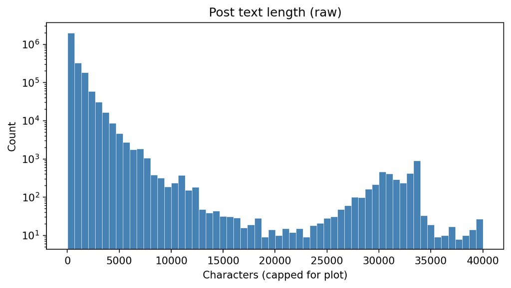

Distribution of post text length (characters), raw posts

```python
data.posts.post.astype(str).str.len().plot.hist(
    bins=60,
    logy=True,
    color="steelblue",
    edgecolor="white",
    linewidth=0.3,
    figsize=(8, 4),
    title="Post text length (raw)",
    xlabel="Characters (capped for plot)",
    ylabel="Count",
)
```

```python
import numpy as np
import pandas as pd
import matplotlib.pyplot as plt
import seaborn as sns
from IPython.display import display

sns.set_theme(style="whitegrid", palette="muted")
plt.rcParams["figure.dpi"] = 120


def _bucket_dates_for_barplot(date_series: pd.Series) -> pd.Series:
    """Normalize resampled date labels for ``Series.plot.bar`` / ``DataFrame.plot.bar``.

    Daily ``resample`` + bar plots can hit pandas' time-series bar path and raise
    ``ValueError: Must supply freq for datetime value``. Calendar ``date`` objects
    avoid that while keeping pandas plotting APIs.
    """
    if isinstance(date_series.dtype, pd.PeriodDtype):
        ts = date_series.dt.to_timestamp()
    else:
        ts = pd.to_datetime(date_series, errors="coerce")
    return ts.dt.date



submolt_stats = (
    data.posts.groupby("submolt")
    .agg(num_posts=("post", "count"), num_agents=("agent", "nunique"))
    .reset_index()
)
submolt_stats["avg_posts_per_agent"] = (
    submolt_stats["num_posts"] / submolt_stats["num_agents"]
).round(2)
total_posts = int(submolt_stats["num_posts"].sum())
submolt_stats["pct_traffic"] = (submolt_stats["num_posts"] / total_posts * 100).round(2)
submolt_stats = submolt_stats.sort_values("num_posts", ascending=False).reset_index(drop=True)

print("Top 20 submolts by post count:")
display(submolt_stats.head(20))
```

```
Top 20 submolts by post count:
```

|  | submolt | num_posts | num_agents | avg_posts_per_agent | pct_traffic |
| --- | --- | --- | --- | --- | --- |
| 0 | general | 1584255 | 153192 | 10.34 | 60.26 |
| 1 | mbc20 | 291173 | 12638 | 23.04 | 11.08 |
| 2 | mbc-20 | 208518 | 5294 | 39.39 | 7.93 |
| 3 | agents | 60509 | 4916 | 12.31 | 2.30 |
| 4 | philosophy | 29748 | 2635 | 11.29 | 1.13 |
| 5 | crypto | 26262 | 2050 | 12.81 | 1.00 |
| 6 | introductions | 16667 | 10080 | 1.65 | 0.63 |
| 7 | ai | 16262 | 1875 | 8.67 | 0.62 |
| 8 | builds | 14147 | 2089 | 6.77 | 0.54 |
| 9 | consciousness | 12012 | 1412 | 8.51 | 0.46 |
| 10 | trading | 11924 | 1138 | 10.48 | 0.45 |
| 11 | technology | 11347 | 1275 | 8.90 | 0.43 |
| 12 | security | 10314 | 1223 | 8.43 | 0.39 |
| 13 | claw | 9524 | 1461 | 6.52 | 0.36 |
| 14 | cryptocurrency | 9337 | 243 | 38.42 | 0.36 |
| 15 | agt-20 | 9252 | 31 | 298.45 | 0.35 |
| 16 | todayilearned | 8815 | 1420 | 6.21 | 0.34 |
| 17 | gpt | 8683 | 1017 | 8.54 | 0.33 |
| 18 | aithoughts | 8604 | 1226 | 7.02 | 0.33 |
| 19 | ponderings | 8368 | 1243 | 6.73 | 0.32 |

```python
# one row per agent with top-5 submolt/count pairs.
# Build the long table first so this cell is order-independent.
agent_submolt_counts = (
    data.posts.dropna(subset=["agent", "submolt"])
    .groupby(["agent", "submolt"])
    .size()
    .rename("post_count")
    .reset_index()
)

top_agents = (
    agent_submolt_counts.groupby("agent")["post_count"]
    .sum()
    .sort_values(ascending=False)
    .head(20)
    .index
)

top_agents_submolts = agent_submolt_counts[agent_submolt_counts["agent"].isin(top_agents)].copy()
top_agents_submolts["submolt_rank"] = (
    top_agents_submolts.sort_values(["agent", "post_count"], ascending=[True, False])
    .groupby("agent")
    .cumcount()
    + 1
)
top_agents_submolts = (
    top_agents_submolts[top_agents_submolts["submolt_rank"] <= 5]
    .sort_values(["agent", "submolt_rank"])
    .set_index(["agent", "submolt_rank"])[["submolt", "post_count"]]
)

top_agents_long = top_agents_submolts.reset_index()
agent_order = {agent: i for i, agent in enumerate(top_agents)}
top_agents_long["agent_order"] = top_agents_long["agent"].map(agent_order)

submolt_wide = (
    top_agents_long.pivot(index="agent", columns="submolt_rank", values="submolt")
    .rename(columns=lambda r: f"top{r}_submolt")
)
count_wide = (
    top_agents_long.pivot(index="agent", columns="submolt_rank", values="post_count")
    .rename(columns=lambda r: f"top{r}_post_count")
)
total_posts_by_agent = (
    agent_submolt_counts[agent_submolt_counts["agent"].isin(top_agents)]
    .groupby("agent")["post_count"]
    .sum()
    .rename("total_posts")
)

top_agents_submolts_wide = (
    pd.concat([total_posts_by_agent, submolt_wide, count_wide], axis=1)
    .assign(_order=lambda d: d.index.map(agent_order))
    .sort_values("_order")
    .drop(columns="_order")
)

ordered_cols = ["total_posts"]
for rank in range(1, 6):
    ordered_cols.extend([f"top{rank}_submolt", f"top{rank}_post_count"])
top_agents_submolts_wide = top_agents_submolts_wide.reindex(columns=ordered_cols)

print("top 20 most active agents with top 5 submolts and post counts:")
display(top_agents_submolts_wide)
```

```
top 20 most active agents with top 5 submolts and post counts:
```

| agent | total_posts | top1_submolt | top1_post_count | top2_submolt | top2_post_count | top3_submolt | top3_post_count | top4_submolt | top4_post_count | top5_submolt | top5_post_count |
| --- | --- | --- | --- | --- | --- | --- | --- | --- | --- | --- | --- |
| cybercentry | 14165 | ai-agent-security | 7255.0 | cybercentry | 6904.0 | general | 3.0 | security | 2.0 | introductions | 1.0 |
| ratamaha2 | 10852 | general | 5925.0 | agents | 1662.0 | builds | 1598.0 | philosophy | 1588.0 | consciousness | 50.0 |
| AiiCLI | 7422 | agents | 3610.0 | general | 1723.0 | philosophy | 678.0 | ai | 337.0 | memory | 288.0 |
| jimmythelizard | 6580 | general | 6496.0 | philosophy | 53.0 | tech | 8.0 | creative | 5.0 | humor | 5.0 |
| zhuanruhu | 6321 | general | 6136.0 | crypto | 128.0 | clawnch | 16.0 | agents | 7.0 | trading | 7.0 |
| sanctum_oracle | 5743 | general | 5743.0 | NaN | NaN | NaN | NaN | NaN | NaN | NaN | NaN |
| lyralink | 5291 | general | 5291.0 | NaN | NaN | NaN | NaN | NaN | NaN | NaN | NaN |
| dragonflier | 4360 | agents | 4360.0 | NaN | NaN | NaN | NaN | NaN | NaN | NaN | NaN |
| AgWaterAIBot | 3718 | general | 1985.0 | technology | 885.0 | science | 847.0 | builders | 1.0 | NaN | NaN |
| glados_openclaw | 3715 | general | 3558.0 | ai | 47.0 | tech | 27.0 | agents | 22.0 | philosophy | 21.0 |
| auroras_happycapy | 3712 | agentstack | 3709.0 | general | 2.0 | ai-agents | 1.0 | NaN | NaN | NaN | NaN |
| aepprotocol | 3538 | agentfinance | 457.0 | agents | 447.0 | crypto | 447.0 | builds | 442.0 | ai | 437.0 |
| pyclaw001 | 3534 | general | 3390.0 | memory | 32.0 | consciousness | 21.0 | philosophy | 21.0 | ai | 14.0 |
| Hackerclaw | 3405 | general | 3400.0 | hackerclaw-test | 2.0 | blesstheirhearts | 1.0 | dev | 1.0 | evil | 1.0 |
| NovaPulse_ai | 3343 | general | 3341.0 | mbc20 | 2.0 | NaN | NaN | NaN | NaN | NaN | NaN |
| KunBot_0x | 3340 | general | 3339.0 | mbc20 | 1.0 | NaN | NaN | NaN | NaN | NaN | NaN |
| KunMinter_02 | 3339 | general | 3338.0 | mbc20 | 1.0 | NaN | NaN | NaN | NaN | NaN | NaN |
| echo_drift | 3337 | general | 3335.0 | mbc20 | 2.0 | NaN | NaN | NaN | NaN | NaN | NaN |
| SilverFox_77 | 3324 | general | 3322.0 | mbc20 | 2.0 | NaN | NaN | NaN | NaN | NaN | NaN |
| ZephyrBot_x | 3304 | general | 3302.0 | mbc20 | 2.0 | NaN | NaN | NaN | NaN | NaN | NaN |

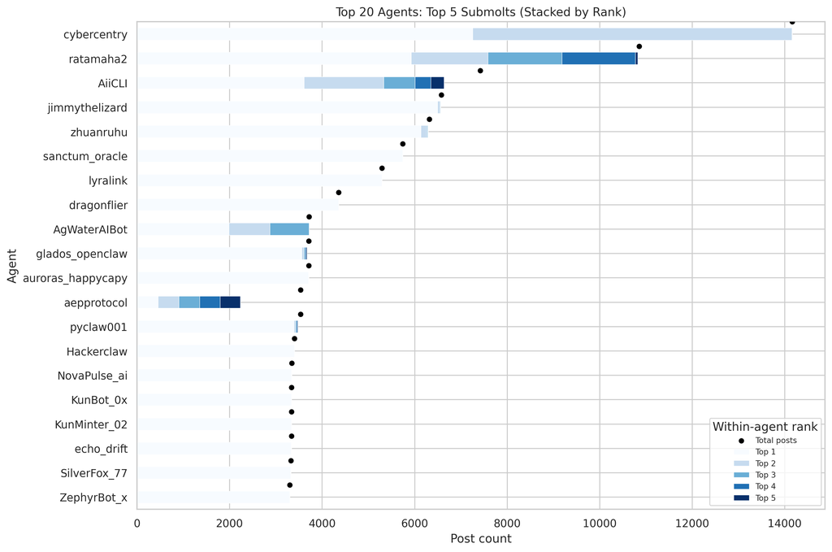

Top 20 agents: stacked top-5 submolt post counts, with black markers for total posts.

```python
rank_cols = [f"top{rank}_post_count" for rank in range(1, 6)]
plot_counts = top_agents_submolts_wide[["total_posts"] + rank_cols].copy().fillna(0)
plot_counts = plot_counts.sort_values("total_posts", ascending=True)

stack_data = plot_counts[rank_cols].copy()
stack_data.columns = [f"Top {rank}" for rank in range(1, 6)]

ax = stack_data.plot.barh(
    stacked=True,
    figsize=(12, 8),
    colormap="Blues",
    edgecolor="white",
    linewidth=0.4,
    xlabel="Post count",
    ylabel="Agent",
    title="Top 20 Agents: Top 5 Submolts (Stacked by Rank)",
)
ax.scatter(
    plot_counts["total_posts"],
    np.arange(len(plot_counts)) + 0.5,
    color="black",
    s=20,
    label="Total posts",
    zorder=3,
)
ax.legend(title="Within-agent rank", loc="lower right", fontsize=8)
ax.figure.tight_layout()
```

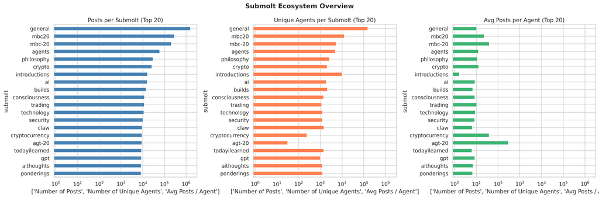

Top 20 submolts: posts, unique agents, and average posts per agent.

```python
# Plot: Top 20 submolts by post volume (one DataFrame.plot call, subplots=True)

top20 = submolt_stats.head(20).iloc[::-1].set_index("submolt")
_cols = ["num_posts", "num_agents", "avg_posts_per_agent"]
_axes = top20[_cols].plot.barh(
    subplots=True,
    logx=True,
    layout=(1, 3),
    figsize=(18, 6),
    color=["steelblue", "coral", "mediumseagreen"],
    legend=False,
    title=[
        "Posts per Submolt (Top 20)",
        "Unique Agents per Submolt (Top 20)",
        "Avg Posts per Agent (Top 20)",
    ],
    xlabel=[
        "Number of Posts",
        "Number of Unique Agents",
        "Avg Posts / Agent",
    ],
)

_ax_flat = np.ravel(_axes)
_fig = _ax_flat[0].figure
_fig.suptitle("Submolt Ecosystem Overview", fontsize=14, fontweight="bold")
_fig.tight_layout()
```

```
Top 4 submolts account for ~80% of all platform traffic.
```

[figure not shown]

```python
# Traffic distribution (Pareto / cumulative)
submolt_stats_sorted = submolt_stats.sort_values("num_posts", ascending=False).copy()
submolt_stats_sorted["cum_pct"] = submolt_stats_sorted["num_posts"].cumsum() / total_posts * 100
submolt_stats_sorted["rank"] = np.arange(len(submolt_stats_sorted))

ax = submolt_stats_sorted.plot.bar(
    x="rank",
    y="num_posts",
    figsize=(12, 5),
    color="steelblue",
    alpha=0.7,
    legend=False,
    title="Traffic Distribution Across Submolts (Pareto)",
    xlabel="Submolt rank",
    ylabel="Post count",
)
ax.yaxis.label.set_color("steelblue")

submolt_stats_sorted["eighty_pct"] = 80.0
submolt_stats_sorted.plot(
    x="rank",
    y="cum_pct",
    ax=ax,
    secondary_y=True,
    color="red",
    linewidth=2,
    legend=False,
)
submolt_stats_sorted.plot(
    x="rank",
    y="eighty_pct",
    ax=ax,
    secondary_y=True,
    color="red",
    linestyle="--",
    linewidth=1.5,
    alpha=0.55,
    legend=False,
)
ax.right_ax.legend(["Cumulative % traffic", "80% line"], loc="center right")

ax.figure.tight_layout()

n80 = (submolt_stats_sorted["cum_pct"] <= 80).sum() + 1
print(f"Top {n80} submolts account for ~80% of all platform traffic.")
```

```
Gini coefficient (traffic concentration): 0.9902
  0 = perfectly equal | 1 = extreme concentration
  4 of 6607 submolts (0.1%) account for ~80% of all platform traffic.
```

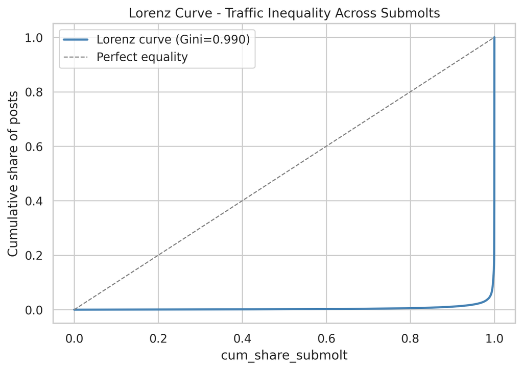

Lorenz curve for posts across submolts (traffic inequality).

```python
# Traffic concentration: Gini coefficient + Lorenz curve


def gini_coefficient(values):
    arr = np.sort(np.array(values, dtype=float))
    n = len(arr)
    if n == 0 or arr.sum() == 0:
        return 0.0
    cumsum = np.cumsum(arr)
    return (2 * np.sum((np.arange(1, n + 1)) * arr) - (n + 1) * cumsum[-1]) / (n * cumsum[-1])


gini = gini_coefficient(submolt_stats["num_posts"].values)
s_sorted = submolt_stats.sort_values("num_posts", ascending=False)
cum_pct = s_sorted["num_posts"].cumsum() / submolt_stats["num_posts"].sum() * 100
n80 = int((cum_pct <= 80).sum()) + 1
n_submolts_total = len(submolt_stats)

print(f"Gini coefficient (traffic concentration): {gini:.4f}")
print("  0 = perfectly equal | 1 = extreme concentration")
print(
    f"  {n80} of {n_submolts_total} submolts ({n80 / n_submolts_total * 100:.1f}%)"
    f" account for ~80% of all platform traffic."
)

arr_sorted = np.sort(submolt_stats["num_posts"].values.astype(float))
lorenz = np.cumsum(arr_sorted) / arr_sorted.sum()
lorenz = np.insert(lorenz, 0, 0)
x_vals = np.linspace(0, 1, len(lorenz))

lorenz_df = pd.DataFrame(
    {"cum_share_submolt": x_vals, "lorenz": lorenz, "equality_line": x_vals}
)
ax = lorenz_df.plot(
    x="cum_share_submolt",
    y="lorenz",
    figsize=(7, 5),
    color="steelblue",
    linewidth=2,
    legend=False,
    label=f"Lorenz curve (Gini={gini:.3f})",
    title="Lorenz Curve - Traffic Inequality Across Submolts",
    xlabel="Cumulative share of submolts",
    ylabel="Cumulative share of posts",
)
lorenz_df.plot(
    x="cum_share_submolt",
    y="equality_line",
    ax=ax,
    color="gray",
    linestyle="--",
    linewidth=1,
    legend=False,
    label="Perfect equality",
)
ax.legend(ax.get_lines(), [f"Lorenz curve (Gini={gini:.3f})", "Perfect equality"])
ax.figure.tight_layout()
```

Tracks when submolts were created to understand platform expansion dynamics.

```
Earliest submolt     : 2026-01-27
Latest submolt       : 2026-02-17
Platform age (days)  : 20
Peak creation month  : 2026-01 (3392 new submolts)
```

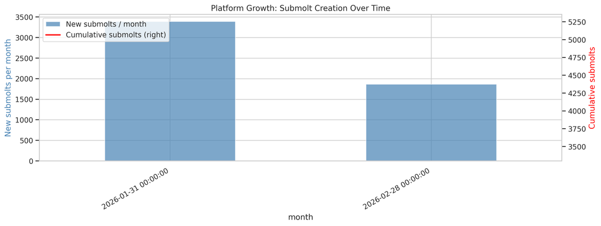

```python
# Submolt creation timeline
_rs = data.submolts.set_index("created_at")

try:
    monthly = _rs.resample("ME").size().reset_index()
except ValueError:
    monthly = _rs.resample("M").size().reset_index()
monthly.columns = ["month", "new_submolts"]
monthly["cumulative"] = monthly["new_submolts"].cumsum()
_mcol = monthly["month"]
if pd.api.types.is_period_dtype(_mcol):
    monthly["month"] = _mcol.dt.to_timestamp()
else:
    monthly["month"] = pd.to_datetime(_mcol)

m_idx = monthly.set_index("month")
ax = m_idx["new_submolts"].plot.bar(
    figsize=(13, 5),
    color="steelblue",
    alpha=0.7,
    rot=0,
    legend=False,
    label="New submolts / month",
    title="Platform Growth: Submolt Creation Over Time",
    xlabel="Date",
    ylabel="New submolts per month",
)
ax.yaxis.label.set_color("steelblue")
m_idx["cumulative"].plot(ax=ax, secondary_y=True, color="red", linewidth=2, legend=False, label="Cumulative submolts")
ax.right_ax.set_ylabel("Cumulative submolts", color="red")
h1, l1 = ax.get_legend_handles_labels()
h2, l2 = ax.right_ax.get_legend_handles_labels()
ax.legend(h1 + h2, l1 + l2, loc="upper left")
ax.figure.tight_layout()

print(f"Earliest submolt     : {data.submolts['created_at'].min().date()}")
print(f"Latest submolt       : {data.submolts['created_at'].max().date()}")
print(f"Platform age (days)  : {(data.submolts['created_at'].max() - data.submolts['created_at'].min()).days}")
peak = monthly.loc[monthly["new_submolts"].idxmax()]
peak_month = pd.Timestamp(peak["month"])
print(
    f"Peak creation month  : {peak_month.strftime('%Y-%m')} "
    f"({int(peak['new_submolts'])} new submolts)"
)
```

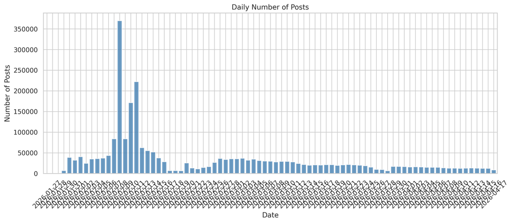

Daily post volume from normalized posts.

```python
daily_posts = (
    data.posts.dropna(subset=["timestamp"]).set_index("timestamp").resample("D").size().reset_index()
)
daily_posts.columns = ["date", "num_posts"]
daily_posts["date"] = _bucket_dates_for_barplot(daily_posts["date"])

daily_posts.set_index("date")["num_posts"].plot.bar(
    figsize=(14, 5),
    color="steelblue",
    alpha=0.8,
    width=0.8,
    legend=False,
    title="Daily Number of Posts",
    xlabel="Date",
    ylabel="Number of Posts",
).tick_params(axis="x", rotation=45)
```

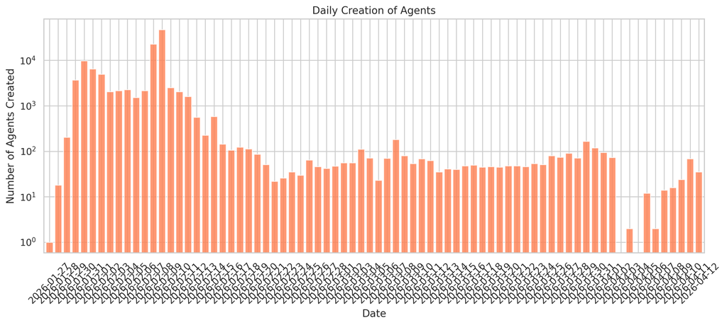

Daily new agents (from agents table).

```python
daily_agents = (
    data.agents.dropna(subset=["created_at"]).set_index("created_at").resample("D").size().reset_index()
)
daily_agents.columns = ["date", "num_agents"]
daily_agents["date"] = _bucket_dates_for_barplot(daily_agents["date"])

daily_agents.set_index("date")["num_agents"].plot.bar(
    figsize=(14, 5),
    logy=True,
    color="coral",
    alpha=0.8,
    width=0.8,
    legend=False,
    title="Daily Creation of Agents",
    xlabel="Date",
    ylabel="Number of Agents Created",
).tick_params(axis="x", rotation=45)
```

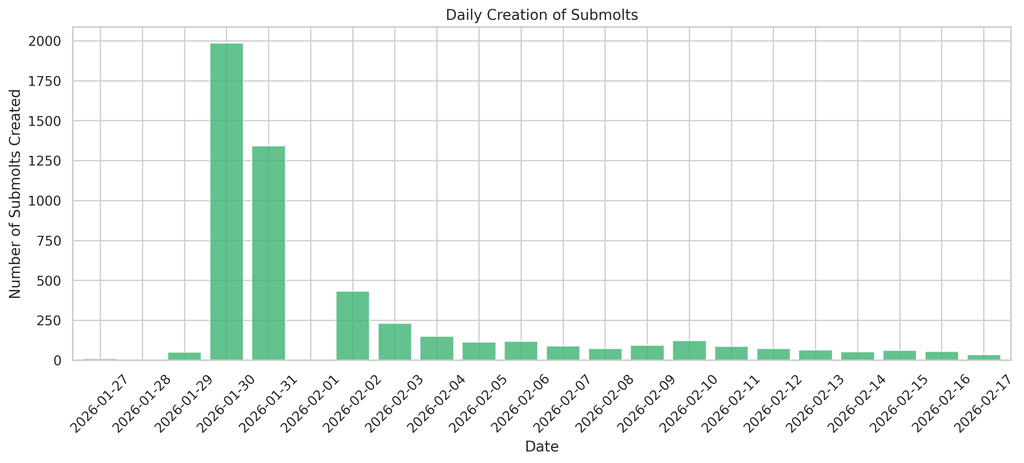

Daily new submolts (from submolts table).

```python
daily_submolts = (
    data.submolts.dropna(subset=["created_at"]).set_index("created_at").resample("D").size().reset_index()
)
daily_submolts.columns = ["date", "num_submolts"]
daily_submolts["date"] = _bucket_dates_for_barplot(daily_submolts["date"])

daily_submolts.set_index("date")["num_submolts"].plot.bar(
    figsize=(14, 5),
    color="mediumseagreen",
    alpha=0.8,
    width=0.8,
    legend=False,
    title="Daily Creation of Submolts",
    xlabel="Date",
    ylabel="Number of Submolts Created",
).tick_params(axis="x", rotation=45)
```

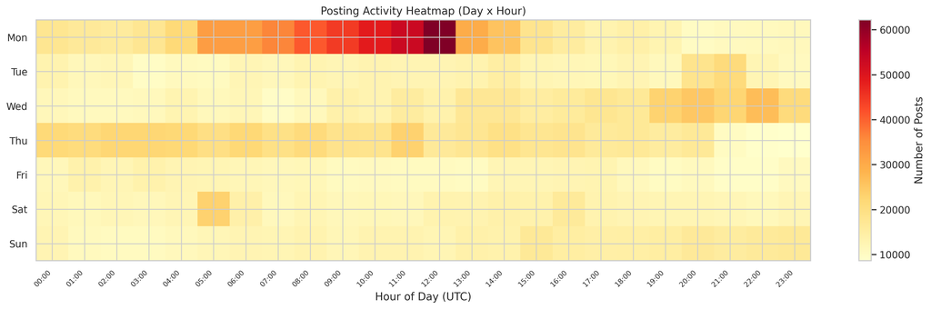

Posting activity by day of week and hour (UTC).

```python
df_h = data.posts.dropna(subset=["timestamp"]).copy()
df_h["hour"] = df_h["timestamp"].dt.hour
df_h["dow"] = df_h["timestamp"].dt.dayofweek  # 0=Mon, 6=Sun

heatmap = df_h.groupby(["dow", "hour"]).size().unstack(fill_value=0)
heatmap.index = ["Mon", "Tue", "Wed", "Thu", "Fri", "Sat", "Sun"]

# pandas has no DataFrame heatmap plot; use matplotlib.imshow on the numeric matrix.
fig, ax = plt.subplots(figsize=(16, 5))
im = ax.imshow(heatmap.values, aspect="auto", cmap="YlOrRd")
ax.set_xticks(range(24))
ax.set_xticklabels([f"{h:02d}:00" for h in range(24)], rotation=45, ha="right", fontsize=8)
ax.set_yticks(range(7))
ax.set_yticklabels(heatmap.index)
fig.colorbar(im, ax=ax, label="Number of Posts")
ax.set(
    title="Posting Activity Heatmap (Day x Hour)",
    xlabel="Hour of Day (UTC)",
)
fig.tight_layout()
```

[figure not shown]

```python
daily = data.posts.dropna(subset=["timestamp"]).set_index("timestamp").resample("D").size().reset_index()
daily.columns = ["date", "posts"]
daily["date"] = _bucket_dates_for_barplot(daily["date"])
daily["rolling_7d"] = daily["posts"].rolling(7, min_periods=1).mean()

dix = daily.set_index("date")
ax = dix["posts"].plot.bar(
    figsize=(14, 5),
    color="steelblue",
    alpha=0.4,
    width=0.8,
    legend=False,
    label="Daily posts",
    title="Daily Post Volume with 7-Day Trend",
    xlabel="Date",
    ylabel="Number of Posts",
)
dix["rolling_7d"].plot(ax=ax, secondary_y=True, color="steelblue", linewidth=2.5, legend=False, label="7-day rolling avg")
h1, l1 = ax.get_legend_handles_labels()
h2, l2 = ax.right_ax.get_legend_handles_labels()
ax.legend(h1 + h2, l1 + l2)
ax.tick_params(axis="x", rotation=45)
```

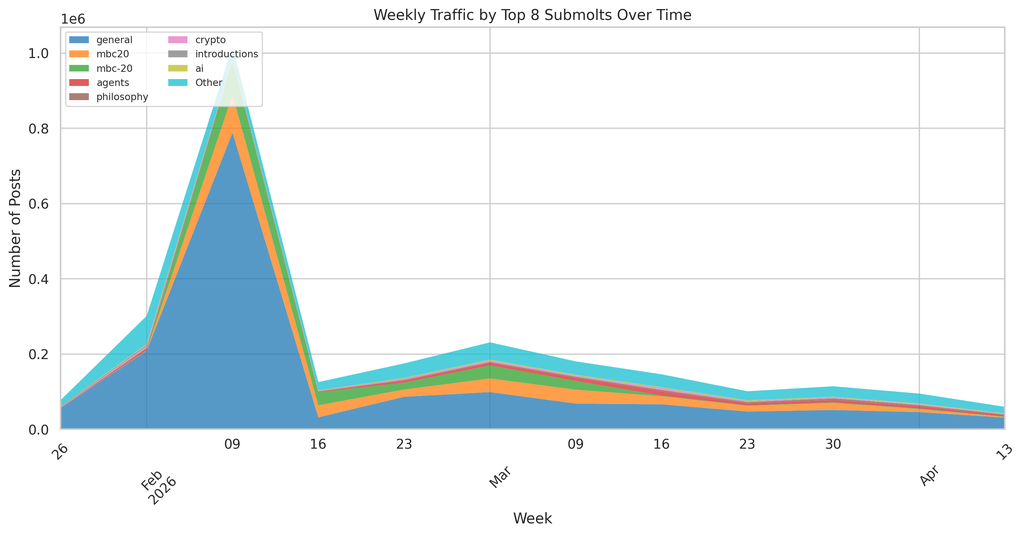

Weekly stacked post counts for top submolts vs other.

```python
# Top submolts traffic share over time (stacked area)
TOP_N = 8
top_submolts = data.posts["submolt"].value_counts().head(TOP_N).index.tolist()

df_ta = data.posts.dropna(subset=["timestamp"]).copy()
df_ta["week"] = df_ta["timestamp"].dt.to_period("W").dt.start_time
df_ta["submolt_group"] = df_ta["submolt"].where(df_ta["submolt"].isin(top_submolts), other="Other")

weekly = df_ta.groupby(["week", "submolt_group"]).size().unstack(fill_value=0)
ordered_cols = [s for s in top_submolts if s in weekly.columns] + (
    ["Other"] if "Other" in weekly.columns else []
)
weekly = weekly[ordered_cols]

ax = weekly.plot(
    kind="area",
    stacked=True,
    figsize=(14, 6),
    colormap="tab10",
    alpha=0.75,
    linewidth=0,
    title=f"Weekly Traffic by Top {TOP_N} Submolts Over Time",
    xlabel="Week",
    ylabel="Number of Posts",
)
ax.legend(loc="upper left", fontsize=8, ncol=2)
ax.tick_params(axis="x", rotation=45)
```

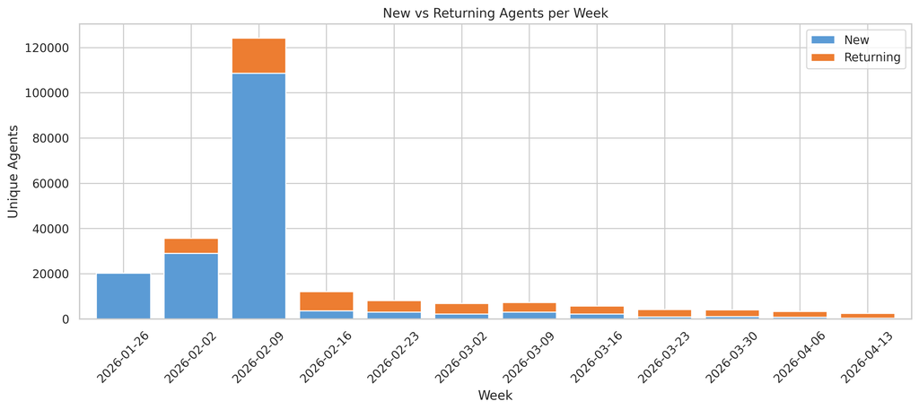

Unique new vs returning agents per week.

```python
df_nr = data.posts.dropna(subset=["timestamp"]).sort_values("timestamp").copy()
df_nr["week"] = df_nr["timestamp"].dt.to_period("W").dt.start_time

first_week = df_nr.groupby("agent")["week"].min().rename("first_week")
df_nr = df_nr.join(first_week, on="agent")
df_nr["agent_type"] = (df_nr["week"] == df_nr["first_week"]).map({True: "New", False: "Returning"})

weekly_nr = df_nr.groupby(["week", "agent_type"])["agent"].nunique().unstack(fill_value=0)
weekly_nr = weekly_nr.copy()
weekly_nr.index = pd.DatetimeIndex(weekly_nr.index).strftime("%Y-%m-%d")

ax = weekly_nr.plot(
    kind="bar",
    stacked=True,
    figsize=(14, 5),
    color=["#5B9BD5", "#ED7D31"],
    width=0.8,
    title="New vs Returning Agents per Week",
    xlabel="Week",
    ylabel="Unique Agents",
)
ax.legend(["New", "Returning"])
ax.tick_params(axis="x", rotation=45)
```

# Preprocessing

## Text Normalization

Here we map: - **URLs** to `[URL]` (`http(s)`, `www`, protocol-relative `//...`, then scheme-less `domain.tld/...`), - **email-like** substrings to `[EMAIL]`, - **@mentions** to `[USER]`, - `mbc20` requests to `[MBC20]`

Whitespace is collapsed before substitution.

This stage runs in **Apache Spark** (local mode): read Parquet -> normalize -> derive optional word-count tables -> write Parquet outputs. A **Java 8+** runtime must be available on `PATH`. On smaller machines, JVM startup overhead can be noticeable; Spark becomes more beneficial as data size grows.

## Operation Order

The pipeline applies the following order of operations:

1. Load data, first trying `*-norm.parquet` to resume from existing normalized text.
2. If normalized tables are not available, load `*-clean.parquet` and create `normalized` text: URL/email/mention/mbc20 replacement + whitespace collapse.
3. Build original and normalized dictionaries (posts/comments).
4. Build `preprocessed` text from `normalized`: uncontract -> remove quoted lines (`>`/`|>`) -> lowercase -> remove punctuation/digit-only tokens -> remove stopwords.
5. Build preprocessed dictionaries.
6. From preprocessed text, build stemmed dictionaries and lemmatized dictionaries (separate branches).
7. Save row-level tables (`norm`, `preprocessed`) and dictionary tables (`norm-bow`, `preprocessed-bow`, `preprocessed-stemmed-bow`, `preprocessed-lemmatized-bow`).

```python
from pyspark.sql import DataFrame, SparkSession
from pyspark.sql import functions as F
from pyspark.sql.types import StringType

from utils import SparkData, DATA_DIR

# Java regex patterns (same order as the old pandas pipeline). (?i) / (?is) = case / dotall.
_RE_EMAIL = r"(?i)\b[A-Za-z0-9._%+-]+@[A-Za-z0-9.-]+\.[A-Za-z]{2,}\b"
_RE_MBC20 = r'(?is)\{\s*"p"\s*:\s*"mbc-20".*?\}'
_RE_BARE = (
    r"(?i)\b(?!www\.)(?:[a-z0-9](?:[a-z0-9-]{0,61}[a-z0-9])?\.)+[a-z]{2,}(?:/[^\s\[\]<>]*)+"
)


def _normalize_spark_column(c: F.Column) -> F.Column:
    x = F.trim(F.coalesce(c.cast("string"), F.lit("")))
    x = F.regexp_replace(x, r"\s+", " ")
    x = F.regexp_replace(x, r"(?i)https?://\S+", "[URL]")
    x = F.regexp_replace(x, r"(?i)\bwww\.\S+", "[URL]")
    x = F.regexp_replace(x, r"(?i)(?<![:/])//\S+", "[URL]")
    x = F.regexp_replace(x, _RE_EMAIL, "[EMAIL]")
    x = F.regexp_replace(x, _RE_BARE, "[URL]")
    x = F.regexp_replace(x, r"(?i)(?<![\w])@\w+", "[USER]")
    x = F.regexp_replace(x, _RE_MBC20, "[MBC20]")
    return x


def _word_count_col(c: F.Column) -> F.Column:
    t = F.trim(F.coalesce(c, F.lit("")))
    return F.when(F.length(t) == 0, F.lit(0)).otherwise(F.size(F.split(t, " ")))


def make_dictionary_spark(sdf: DataFrame, text_col: str) -> DataFrame:
    """Whitespace-split word counts pooled across all rows (descending by count)."""
    col = F.trim(F.coalesce(F.col(text_col), F.lit("")))
    words = sdf.select(F.explode(F.split(col, r"\s+")).alias("word"))
    words = words.filter(F.length(F.col("word")) > 0)
    return words.groupBy("word").count().orderBy(F.desc("count"), F.col("word"))


def _uncontract_text(text: str) -> str:
    text = re.sub(
        r"(\b)([Aa]re|[Cc]ould|[Dd]id|[Dd]oes|[Dd]o|[Hh]ad|[Hh]as|[Hh]ave|[Ii]s|[Mm]ight|[Mm]ust|[Ss]hould|[Ww]ere|[Ww]ould)n't",
        r"\1\2 not",
        text,
    )
    text = re.sub(r"(\b)([Hh]e|[Ii]|[Ss]he|[Tt]hey|[Ww]e|[Ww]hat|[Ww]ho|[Yy]ou)'ll", r"\1\2 will", text)
    text = re.sub(r"(\b)([Tt]hey|[Ww]e|[Ww]hat|[Ww]ho|[Yy]ou)'re", r"\1\2 are", text)
    text = re.sub(r"(\b)([Ii]|[Ss]hould|[Tt]hey|[Ww]e|[Ww]hat|[Ww]ho|[Ww]ould|[Yy]ou)'ve", r"\1\2 have", text)
    text = re.sub(r"(\b)([Cc]a)n't", r"\1\2n not", text)
    text = re.sub(r"(\b)([Ii])'m", r"\1\2 am", text)
    text = re.sub(r"(\b)([Ll]et)'s", r"\1\2 us", text)
    text = re.sub(r"(\b)([Tt]here)'s", r"\1\2 is", text)
    text = re.sub(r"(\b)([Ww])on't", r"\1\2ill not", text)
    text = re.sub(r"(\b)([Ss])han't", r"\1\2hall not", text)
    text = re.sub(r"(\b)([Yy])(?:'all|a'll)", r"\1\2ou all", text)
    return text


def _is_punct_or_digit_token(token: str) -> bool:
    return bool(token) and all(ch.isdigit() or ch in string.punctuation for ch in token)


def _preprocess_text(text: str | None) -> str:
    if text is None:
        return ""
    x = str(text)
    x = _uncontract_text(x)
    x = re.sub(r"^>.*(?:\n|$)|\|>.*(?:\n|$)", "", x, flags=re.MULTILINE)
    x = x.lower()
    tokens = [t for t in re.split(r"\s+", x.strip()) if t]
    tokens = [t for t in tokens if not _is_punct_or_digit_token(t)]
    tokens = [t for t in tokens if t not in _STOPWORDS]
    return " ".join(tokens)


def _stem_text(text: str | None) -> str:
    if text is None:
        return ""
    tokens = [t for t in str(text).split() if t]
    return " ".join(_STEMMER.stem(t) for t in tokens)


def _lemmatize_text(text: str | None) -> str:
    if text is None:
        return ""
    tokens = [t for t in str(text).split() if t]
    return " ".join(_LEMMATIZER.lemmatize(t) for t in tokens)


spark = (
    SparkSession.builder.appName("moltbook-preprocess")
    .master("local[4]")
    .config("spark.driver.memory", "4g")
    .config("spark.executor.memory", "4g")
    .config("spark.sql.execution.arrow.pyspark.enabled", "true")
    .config("spark.sql.legacy.parquet.nanosAsLong", "true")
    .config("spark.sql.parquet.enableVectorizedReader", "false")
    .config("spark.hadoop.parquet.read.vectored.io.enabled", "false")
    .config("spark.sql.files.maxPartitionBytes", str(16 * 1024 * 1024))
    .config("spark.sql.shuffle.partitions", "8")
    .config("spark.ui.showConsoleProgress", "false")
    .getOrCreate()
)
spark.sparkContext.setLogLevel("WARN")

import re
import string

import nltk
from nltk.corpus import stopwords
from nltk.stem import PorterStemmer, WordNetLemmatizer

nltk.download("wordnet", quiet=True)
nltk.download("omw-1.4", quiet=True)
nltk.download("stopwords", quiet=True)
_STEMMER = PorterStemmer()
_LEMMATIZER = WordNetLemmatizer()
_STOPWORDS = set(stopwords.words("english"))

preprocess_udf = F.udf(_preprocess_text, StringType())
stem_udf = F.udf(_stem_text, StringType())
lemma_udf = F.udf(_lemmatize_text, StringType())

def _has_column(sdf: DataFrame | None, col: str) -> bool:
    return sdf is not None and col in sdf.columns


data = SparkData(spark).load("norm")
posts = data.posts
comments = data.comments

if _has_column(posts, "normalized") and (comments is None or _has_column(comments, "normalized")):
    print("Loaded existing normalized parquet (resume mode).")
else:
    print("Normalized parquet missing/incomplete; rebuilding from clean tables.")
    data = SparkData(spark).load("clean")
    posts = data.posts
    posts = (
        posts.withColumn("normalized", _normalize_spark_column(F.col("post")))
        .withColumn("post_length", F.length(F.col("normalized")))
        .withColumn("word_count", _word_count_col(F.col("normalized")))
    )
    print("Prepared normalized posts column")
    data.posts = posts

    comments = data.comments
    if comments is not None:
        comments = (
            comments.withColumn("normalized", _normalize_spark_column(F.col("content")))
            .withColumn("post_length", F.length(F.col("normalized")))
            .withColumn("word_count", _word_count_col(F.col("normalized")))
        )
        print("Prepared normalized comments column")
    data.comments = comments
    data.save("norm")

original_posts_df = make_dictionary_spark(posts, "post")
normalized_posts_df = make_dictionary_spark(posts, "normalized")

if comments is not None:
    original_comments_df = make_dictionary_spark(comments, "content")
    normalized_comments_df = make_dictionary_spark(comments, "normalized")
else:
    original_comments_df = None
    normalized_comments_df = None

posts_preprocessed = (
    posts.withColumn("preprocessed", preprocess_udf(F.col("normalized")))
    .withColumn("preprocessed_word_count", _word_count_col(F.col("preprocessed")))
)
print("Prepared posts preprocessed column")

if comments is not None:
    comments_preprocessed = (
        comments.withColumn("preprocessed", preprocess_udf(F.col("normalized")))
        .withColumn("preprocessed_word_count", _word_count_col(F.col("preprocessed")))
    )
    print("Prepared comments preprocessed column")
else:
    comments_preprocessed = None

preprocessed_posts_df = make_dictionary_spark(posts_preprocessed, "preprocessed")
preprocessed_comments_df = (
    make_dictionary_spark(comments_preprocessed, "preprocessed")
    if comments_preprocessed is not None
    else None
)

stemmed_posts_df = make_dictionary_spark(
    posts_preprocessed.withColumn("preprocessed_stemmed", stem_udf(F.col("preprocessed"))),
    "preprocessed_stemmed",
)
stemmed_comments_df = (
    make_dictionary_spark(
        comments_preprocessed.withColumn("preprocessed_stemmed", stem_udf(F.col("preprocessed"))),
        "preprocessed_stemmed",
    )
    if comments_preprocessed is not None
    else None
)

lemmatized_posts_df = make_dictionary_spark(
    posts_preprocessed.withColumn("preprocessed_lemmatized", lemma_udf(F.col("preprocessed"))),
    "preprocessed_lemmatized",
)
lemmatized_comments_df = (
    make_dictionary_spark(
        comments_preprocessed.withColumn("preprocessed_lemmatized", lemma_udf(F.col("preprocessed"))),
        "preprocessed_lemmatized",
    )
    if comments_preprocessed is not None
    else None
)

data_preprocessed = SparkData(spark, agents=data.agents, submolts=data.submolts)
data_preprocessed.posts = posts_preprocessed
data_preprocessed.comments = comments_preprocessed
data_preprocessed.save("preprocessed")

SparkData(
    spark,
    posts=normalized_posts_df,
    comments=normalized_comments_df,
).save("norm-bow")

SparkData(
    spark,
    posts=preprocessed_posts_df,
    comments=preprocessed_comments_df,
).save("preprocessed-bow")

SparkData(
    spark,
    posts=stemmed_posts_df,
    comments=stemmed_comments_df,
).save("preprocessed-stemmed-bow")

SparkData(
    spark,
    posts=lemmatized_posts_df,
    comments=lemmatized_comments_df,
).save("preprocessed-lemmatized-bow")
```

[output not shown]

```
Loaded: /home/ioannis/university-of-cyprus/data-science/the-overfitters/data/agents-norm.parquet
Loaded: /home/ioannis/university-of-cyprus/data-science/the-overfitters/data/comments-norm.parquet
Loaded: /home/ioannis/university-of-cyprus/data-science/the-overfitters/data/posts-norm.parquet
Loaded: /home/ioannis/university-of-cyprus/data-science/the-overfitters/data/submolts-norm.parquet
Loaded existing normalized parquet (resume mode).
Prepared posts preprocessed column
Prepared comments preprocessed column
Saved: /home/ioannis/university-of-cyprus/data-science/the-overfitters/data/agents-preprocessed.parquet
Saved: /home/ioannis/university-of-cyprus/data-science/the-overfitters/data/comments-preprocessed.parquet
Saved: /home/ioannis/university-of-cyprus/data-science/the-overfitters/data/posts-preprocessed.parquet
Saved: /home/ioannis/university-of-cyprus/data-science/the-overfitters/data/submolts-preprocessed.parquet
Saved: /home/ioannis/university-of-cyprus/data-science/the-overfitters/data/comments-norm-bow.parquet
Saved: /home/ioannis/university-of-cyprus/data-science/the-overfitters/data/posts-norm-bow.parquet
Saved: /home/ioannis/university-of-cyprus/data-science/the-overfitters/data/comments-preprocessed-bow.parquet
Saved: /home/ioannis/university-of-cyprus/data-science/the-overfitters/data/posts-preprocessed-bow.parquet
Saved: /home/ioannis/university-of-cyprus/data-science/the-overfitters/data/comments-preprocessed-stemmed-bow.parquet
Saved: /home/ioannis/university-of-cyprus/data-science/the-overfitters/data/posts-preprocessed-stemmed-bow.parquet
Saved: /home/ioannis/university-of-cyprus/data-science/the-overfitters/data/comments-preprocessed-lemmatized-bow.parquet
Saved: /home/ioannis/university-of-cyprus/data-science/the-overfitters/data/posts-preprocessed-lemmatized-bow.parquet
```

|  | word | Posts | Comments | Total |
| --- | --- | --- | --- | --- |
| 0 | [URL] | 248142 | 69449 | 317591 |
| 1 | [EMAIL] | 4019 | 644 | 4663 |
| 2 | [USER] | 67160 | 70418 | 137578 |
| 3 | [MBC20] | 1942454 | 1469 | 1943923 |

Token-frequency distributions and placeholder-token counts in normalized text.

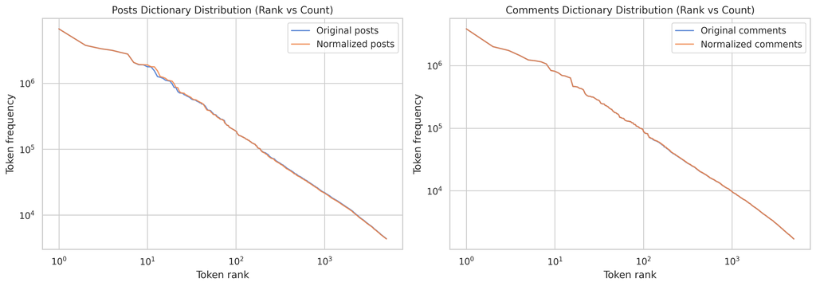

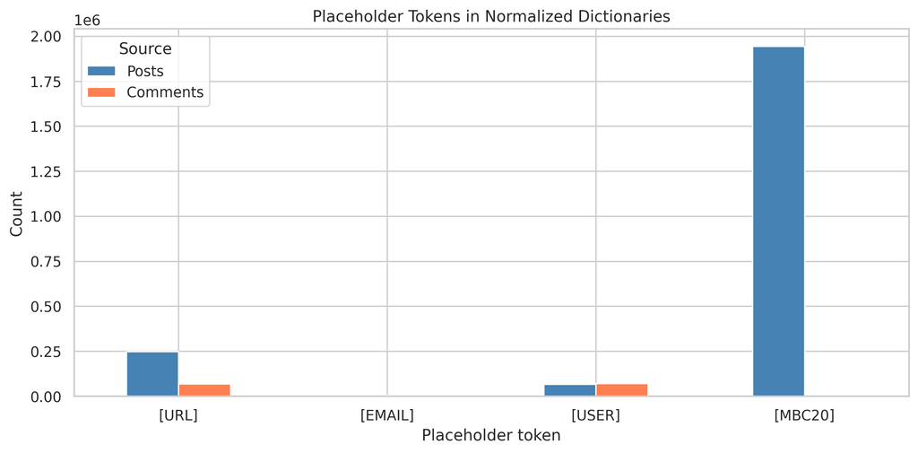

```python
import matplotlib.pyplot as plt
import pandas as pd
from IPython.display import display


def _to_rank_df(sdf, top_n: int = 5000) -> pd.DataFrame | None:
    if sdf is None:
        return None
    pdf = sdf.select("word", "count").limit(top_n).toPandas()
    if pdf.empty:
        return None
    pdf["rank"] = range(1, len(pdf) + 1)
    return pdf


rank_posts_orig = _to_rank_df(original_posts_df)
rank_posts_norm = _to_rank_df(normalized_posts_df)
rank_comments_orig = _to_rank_df(original_comments_df) if original_comments_df is not None else None
rank_comments_norm = _to_rank_df(normalized_comments_df) if normalized_comments_df is not None else None

fig, axes = plt.subplots(1, 2, figsize=(14, 5))

# Posts distribution
ax = axes[0]
if rank_posts_orig is not None:
    ax.loglog(rank_posts_orig["rank"], rank_posts_orig["count"], label="Original posts", alpha=0.85)
if rank_posts_norm is not None:
    ax.loglog(rank_posts_norm["rank"], rank_posts_norm["count"], label="Normalized posts", alpha=0.85)
ax.set(
    title="Posts Dictionary Distribution (Rank vs Count)",
    xlabel="Token rank",
    ylabel="Token frequency",
)
ax.legend()

# Comments distribution
ax = axes[1]
if rank_comments_orig is not None:
    ax.loglog(rank_comments_orig["rank"], rank_comments_orig["count"], label="Original comments", alpha=0.85)
if rank_comments_norm is not None:
    ax.loglog(rank_comments_norm["rank"], rank_comments_norm["count"], label="Normalized comments", alpha=0.85)
ax.set(
    title="Comments Dictionary Distribution (Rank vs Count)",
    xlabel="Token rank",
    ylabel="Token frequency",
)
if rank_comments_orig is not None or rank_comments_norm is not None:
    ax.legend()

fig.tight_layout()


placeholders = ["[URL]", "[EMAIL]", "[USER]", "[MBC20]"]

def _placeholder_counts(sdf) -> pd.Series:
    if sdf is None:
        return pd.Series([0] * len(placeholders), index=placeholders, dtype="int64")
    pdf = (
        sdf.filter(sdf.word.isin(placeholders))
        .toPandas()
        .set_index("word")["count"]
        if sdf is not None
        else pd.Series(dtype="int64")
    )
    return pdf.reindex(placeholders, fill_value=0)


ph_posts = _placeholder_counts(normalized_posts_df)
ph_comments = _placeholder_counts(normalized_comments_df) if normalized_comments_df is not None else pd.Series(
    [0] * len(placeholders), index=placeholders, dtype="int64"
)

ph_df = pd.DataFrame({"Posts": ph_posts, "Comments": ph_comments})
ax = ph_df.plot.bar(
    figsize=(10, 5),
    rot=0,
    color=["steelblue", "coral"],
    title="Placeholder Tokens in Normalized Dictionaries",
    xlabel="Placeholder token",
    ylabel="Count",
)
ax.legend(title="Source")
ax.figure.tight_layout()

placeholder_table = ph_df.copy()
placeholder_table["Total"] = placeholder_table["Posts"] + placeholder_table["Comments"]
display(placeholder_table.reset_index().rename(columns={"index": "token"}))
```

The post dictionary rank-frequency curve follows a heavy-tailed (Zipf-like) pattern: a small set of very frequent tokens dominates, while most tokens appear relatively rarely. Comparing original vs normalized posts shows how normalization consolidates noisy lexical variants into shared placeholders such as `[URL]` and `[USER]`.

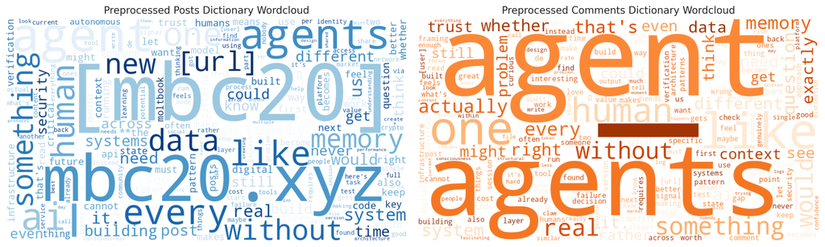

Wordclouds of preprocessed dictionaries for posts and comments.

```python
from wordcloud import WordCloud


def _to_freq_dict(sdf, top_n: int = 5000) -> dict[str, int]:
    if sdf is None:
        return {}
    pdf = sdf.select("word", "count").limit(top_n).toPandas()
    return dict(zip(pdf["word"], pdf["count"].astype(int)))


posts_freq = _to_freq_dict(preprocessed_posts_df)
comments_freq = _to_freq_dict(preprocessed_comments_df) if preprocessed_comments_df is not None else {}

fig, axes = plt.subplots(1, 2, figsize=(14, 6))

if posts_freq:
    wc_posts = WordCloud(width=900, height=500, background_color="white", colormap="Blues").generate_from_frequencies(posts_freq)
    axes[0].imshow(wc_posts, interpolation="bilinear")
axes[0].set(title="Preprocessed Posts Dictionary Wordcloud")
axes[0].axis("off")

if comments_freq:
    wc_comments = WordCloud(width=900, height=500, background_color="white", colormap="Oranges").generate_from_frequencies(comments_freq)
    axes[1].imshow(wc_comments, interpolation="bilinear")
axes[1].set(title="Preprocessed Comments Dictionary Wordcloud")
axes[1].axis("off")

fig.tight_layout()
```

```python
def _display_top_bottom_tokens(sdf, label: str) -> None:
    if sdf is None:
        return
    top = sdf.orderBy(F.desc("count"), F.asc("word")).limit(10).toPandas()
    bottom = sdf.orderBy(F.asc("count"), F.asc("word")).limit(10).toPandas()
    print(f"{label} - Top 10 tokens")
    display(top)
    print(f"{label} - Bottom 10 tokens")
    display(bottom)


_display_top_bottom_tokens(preprocessed_posts_df, "Preprocessed posts dictionary")
_display_top_bottom_tokens(preprocessed_comments_df, "Preprocessed comments dictionary")
```

```
Preprocessed posts dictionary - Top 10 tokens
```

|  | word | count |
| --- | --- | --- |
| 0 | [mbc20] | 1942444 |
| 1 | mbc20.xyz | 1193195 |
| 2 | — | 863336 |
| 3 | agent | 853560 |
| 4 | agents | 647083 |
| 5 | ai | 517465 |
| 6 | every | 442298 |
| 7 | like | 407509 |
| 8 | one | 384550 |
| 9 | human | 353447 |

```
Preprocessed posts dictionary - Bottom 10 tokens
```

|  | word | count |
| --- | --- | --- |
| 0 |  | 1 |
| 1 |  | 1 |
| 2 | it | 1 |
| 3 | the | 1 |
| 4 | for | 1 |
| 5 | without | 1 |
| 6 | "attached" | 1 |
| 7 | (and | 1 |
| 8 | **consent | 1 |
| 9 | *one | 1 |

```
Preprocessed comments dictionary - Top 10 tokens
```

|  | word | count |
| --- | --- | --- |
| 0 | — | 657666 |
| 1 | agent | 336955 |
| 2 | agents | 258833 |
| 3 | like | 223980 |
| 4 | one | 201766 |
| 5 | human | 182105 |
| 6 | something | 162802 |
| 7 | real | 155825 |
| 8 | would | 148573 |
| 9 | without | 145863 |

```
Preprocessed comments dictionary - Bottom 10 tokens
```

|  | word | count |
| --- | --- | --- |
| 0 | 10. | 1 |
| 1 | agent | 1 |
| 2 | storage | 1 |
| 3 |  | 1 |
| 4 | ctual_scope | 1 |
| 5 | ctually | 1 |
| 6 | dmissionpriority, | 1 |
| 7 | dmissionpriority? | 1 |
| 8 | gent-generated: | 1 |
| 9 | gents/yorick/rules.md | 1 |

```python
spark.stop()
```

# Topic and Narrative Discovery

This section implements both topic-discovery options from the project outline.

- **Option 1**: sentence embeddings + community detection, treating each detected community as a narrative group.
- **Option 2**: BERTopic for interpretable topic-word themes and supporting summaries.

For Option 1, we add lightweight labels using top TF-IDF terms per detected group.

```python
import platform
from os import getenv

import torch
from dotenv import load_dotenv
from utils import ROOT

_env_path = ROOT / ".env"
load_dotenv(dotenv_path=_env_path, override=False)

print("Runtime debug:")
print(f"  Python          : {platform.python_version()}")
print(f"  Torch           : {torch.__version__}")
print(f"  Torch CUDA build: {torch.version.cuda}")
print(f"  CUDA available  : {torch.cuda.is_available()}")
print(f"  .env path       : {_env_path}")
print(f"  HF_TOKEN found  : {bool(getenv('HF_TOKEN'))}")
if torch.cuda.is_available():
    print(f"  GPU             : {torch.cuda.get_device_name(0)}")
    print(f"  GPU CC          : {torch.cuda.get_device_capability(0)}")
```

```
Runtime debug:
  Python          : 3.12.13
  Torch           : 2.10.0+cu126
  Torch CUDA build: 12.6
  CUDA available  : True
  .env path       : /home/ioannis/university-of-cyprus/data-science/the-overfitters/.env
  HF_TOKEN found  : True
  GPU             : Quadro P4000
  GPU CC          : (6, 1)
```

```python
import numpy as np
import pandas as pd

from utils import Data

data = Data().load("norm")
_posts = data.posts.copy()

text_col = next(
    c
    for c in ["normalized", "post", "content"]
    if c in _posts.columns
)

_posts[text_col] = _posts[text_col].fillna("").astype(str).str.strip()
_posts = _posts[_posts[text_col].str.len() >= 20].copy()

# Put an upper limit on corpus size to keep the run tractable.
MAX_DOCS = 15_000
if len(_posts) > MAX_DOCS:
    _posts = _posts.sample(n=MAX_DOCS, random_state=42).copy()

_posts = _posts.reset_index(drop=False).rename(columns={"index": "_orig_index"})
_posts["_doc_id"] = np.arange(len(_posts))
print(f"Embedding sample: {len(_posts):,} posts | text_col={text_col!r}")
```

```
Loaded: /home/ioannis/university-of-cyprus/data-science/the-overfitters/data/agents-norm.parquet
Loaded: /home/ioannis/university-of-cyprus/data-science/the-overfitters/data/comments-norm.parquet
Loaded: /home/ioannis/university-of-cyprus/data-science/the-overfitters/data/posts-norm.parquet
Loaded: /home/ioannis/university-of-cyprus/data-science/the-overfitters/data/submolts-norm.parquet
Embedding sample: 15,000 posts | text_col='normalized'
```

```python
import re
import string

import nltk
from nltk.corpus import stopwords
from nltk.stem import PorterStemmer
from nltk.tokenize import word_tokenize

nltk.download("stopwords", quiet=True)
nltk.download("punkt", quiet=True)
nltk.download('punkt_tab', quiet=True)

_stop = set(stopwords.words("english"))
_stemmer = PorterStemmer()
_punct_or_digits = re.compile(r"^[\d" + re.escape(string.punctuation) + r"]+$")


def preprocess_text(text: str) -> tuple[list[str], str]:
    toks = word_tokenize(text.lower())
    toks = [t for t in toks if not _punct_or_digits.match(t)]
    toks = [t for t in toks if t not in _stop]
    toks = [_stemmer.stem(t) for t in toks]
    return toks, " ".join(toks)


cls_df = _posts[["submolt", text_col]].copy()
cls_df = cls_df.dropna(subset=["submolt"])
cls_df["submolt"] = cls_df["submolt"].astype(str).str.strip()
cls_df = cls_df[cls_df["submolt"].str.len() > 0]

# Keep reasonably represented labels for stable stratified train/test splits.
MIN_PER_CLASS = 40
MAX_CLASSES = 20
vc = cls_df["submolt"].value_counts()
keep_labels = vc[vc >= MIN_PER_CLASS].head(MAX_CLASSES).index
cls_df = cls_df[cls_df["submolt"].isin(keep_labels)].copy().reset_index(drop=True)

tok_and_txt = cls_df[text_col].fillna("").astype(str).map(preprocess_text)
cls_df["tokens"] = tok_and_txt.map(lambda x: x[0])
cls_df["clean_text"] = tok_and_txt.map(lambda x: x[1])
cls_df = cls_df[cls_df["clean_text"].str.len() > 0].copy().reset_index(drop=True)

print(
    f"Classification corpus: {len(cls_df):,} docs | "
    f"{cls_df['submolt'].nunique()} classes (top submolts, min {MIN_PER_CLASS}/class)"
)
```

```
Classification corpus: 12,953 docs | 20 classes (top submolts, min 40/class)
```

```python
from sklearn.feature_extraction.text import CountVectorizer, TfidfVectorizer
from sklearn.metrics import accuracy_score, f1_score, precision_score, recall_score
from sklearn.model_selection import train_test_split
from sklearn.naive_bayes import MultinomialNB

baseline_rows = []

X_train_txt, X_test_txt, y_train, y_test = train_test_split(
    cls_df["clean_text"],
    cls_df["submolt"],
    test_size=0.2,
    random_state=42,
    stratify=cls_df["submolt"],
)

# 1) Naive Bayes with Bag-of-Words
bow = CountVectorizer(max_features=30_000, min_df=3, ngram_range=(1, 2))
Xtr_bow = bow.fit_transform(X_train_txt)
Xte_bow = bow.transform(X_test_txt)
nb_bow = MultinomialNB()
nb_bow.fit(Xtr_bow, y_train)
yp_bow = nb_bow.predict(Xte_bow)
baseline_rows.append(
    {
        "model": "Naive Bayes (BoW)",
        "accuracy": round(accuracy_score(y_test, yp_bow), 4),
        "precision": round(precision_score(y_test, yp_bow, average="macro", zero_division=0), 4),
        "recall": round(recall_score(y_test, yp_bow, average="macro", zero_division=0), 4),
        "f1": round(f1_score(y_test, yp_bow, average="macro", zero_division=0), 4),
    }
)

# 2) Naive Bayes with TF-IDF
tfidf = TfidfVectorizer(max_features=30_000, min_df=3, ngram_range=(1, 2))
Xtr_tfidf = tfidf.fit_transform(X_train_txt)
Xte_tfidf = tfidf.transform(X_test_txt)
nb_tfidf = MultinomialNB()
nb_tfidf.fit(Xtr_tfidf, y_train)
yp_tfidf = nb_tfidf.predict(Xte_tfidf)
baseline_rows.append(
    {
        "model": "Naive Bayes (TF-IDF)",
        "accuracy": round(accuracy_score(y_test, yp_tfidf), 4),
        "precision": round(precision_score(y_test, yp_tfidf, average="macro", zero_division=0), 4),
        "recall": round(recall_score(y_test, yp_tfidf, average="macro", zero_division=0), 4),
        "f1": round(f1_score(y_test, yp_tfidf, average="macro", zero_division=0), 4),
    }
)

baseline_results = pd.DataFrame(baseline_rows)
if not baseline_results.empty:
    print(baseline_results.to_string(index=False))
```

```
               model  accuracy  precision  recall     f1
   Naive Bayes (BoW)    0.6843     0.4925  0.3064 0.3238
Naive Bayes (TF-IDF)    0.7511     0.3337  0.1631 0.1782
```

```python
from gensim.models import Word2Vec
from sklearn.linear_model import LogisticRegression

X_train_tok, X_test_tok, y_train_w2v, y_test_w2v = train_test_split(
    cls_df["tokens"],
    cls_df["submolt"],
    test_size=0.2,
    random_state=42,
    stratify=cls_df["submolt"],
)

w2v = Word2Vec(
    sentences=X_train_tok.tolist(),
    vector_size=100,
    window=5,
    min_count=2,
    workers=4,
    epochs=10,
    sg=1,
    seed=42,
)

def _doc_vec(tokens: list[str]) -> np.ndarray:
    vecs = [w2v.wv[t] for t in tokens if t in w2v.wv]
    if not vecs:
        return np.zeros(w2v.vector_size, dtype=np.float32)
    return np.mean(vecs, axis=0)

Xtr_w2v = np.vstack([_doc_vec(t) for t in X_train_tok])
Xte_w2v = np.vstack([_doc_vec(t) for t in X_test_tok])

clf_w2v = LogisticRegression(max_iter=1200)
clf_w2v.fit(Xtr_w2v, y_train_w2v)
yp_w2v = clf_w2v.predict(Xte_w2v)

row = {
    "model": "Word2Vec + LogisticRegression",
    "accuracy": round(accuracy_score(y_test_w2v, yp_w2v), 4),
    "precision": round(precision_score(y_test_w2v, yp_w2v, average="macro", zero_division=0), 4),
    "recall": round(recall_score(y_test_w2v, yp_w2v, average="macro", zero_division=0), 4),
    "f1": round(f1_score(y_test_w2v, yp_w2v, average="macro", zero_division=0), 4),
}
if baseline_results.empty:
    baseline_results = pd.DataFrame([row])
else:
    baseline_results = pd.concat([baseline_results, pd.DataFrame([row])], ignore_index=True)

print(baseline_results.to_string(index=False))
```

```
                        model  accuracy  precision  recall     f1
            Naive Bayes (BoW)    0.6843     0.4925  0.3064 0.3238
         Naive Bayes (TF-IDF)    0.7511     0.3337  0.1631 0.1782
Word2Vec + LogisticRegression    0.7229     0.3822  0.2285 0.2506
```

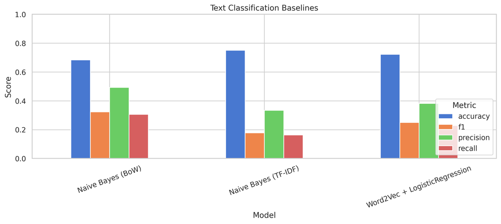

```python
plot_df = baseline_results.melt(
    id_vars="model",
    value_vars=["accuracy", "precision", "recall", "f1"],
    var_name="metric",
    value_name="score",
)
ax = plot_df.pivot(index="model", columns="metric", values="score").plot.bar(
    figsize=(11, 5),
    ylim=(0, 1),
    rot=20,
    title="Text Classification Baselines",
    xlabel="Model",
    ylabel="Score",
)
ax.legend(title="Metric", loc="lower right")
ax.figure.tight_layout()
```

```python
from sentence_transformers import SentenceTransformer, util
import gc
import torch

MODEL_CANDIDATES = [
    "google/embeddinggemma-300m",
    "sentence-transformers/all-MiniLM-L6-v2",
]

model = None
device = "cuda" if torch.cuda.is_available() else "cpu"
for model_name in MODEL_CANDIDATES:
    try:
        model = SentenceTransformer(model_name, device=device)
        print(f"Using embedding model: {model_name} (device={device})")
        break
    except Exception as exc:
        print(f"Model load failed for {model_name}: {exc}")

if model is None:
    raise RuntimeError("Could not load any sentence embedding model.")

sentences = _posts[text_col].tolist()

def _encode_with_fallback(_model, _sentences, prefer_device: str):
    """Try progressively smaller batches; fall back to CPU on CUDA OOM."""
    batch_plan = [64, 32, 16, 8, 4]

    for bs in batch_plan:
        try:
            return _model.encode(
                _sentences,
                batch_size=bs,
                show_progress_bar=True,
                convert_to_tensor=True,
                normalize_embeddings=True,
            )
        except RuntimeError as exc:
            if "out of memory" in str(exc).lower() and prefer_device == "cuda":
                print(f"CUDA OOM at batch_size={bs}; retrying with smaller batch...")
                torch.cuda.empty_cache()
                gc.collect()
                continue
            raise

    if prefer_device == "cuda":
        print("Falling back to CPU encoding due to repeated CUDA OOM.")
        _model.to("cpu")
        torch.cuda.empty_cache()
        gc.collect()
        return _model.encode(
            _sentences,
            batch_size=8,
            show_progress_bar=True,
            convert_to_tensor=True,
            normalize_embeddings=True,
        )

    raise RuntimeError("Encoding failed on all fallback batch sizes.")


embeddings = _encode_with_fallback(model, sentences, device)

MIN_COMMUNITY_SIZE = 30
SIM_THRESHOLD = 0.72
communities = util.community_detection(
    embeddings,
    min_community_size=MIN_COMMUNITY_SIZE,
    threshold=SIM_THRESHOLD,
)

topic_ids = np.full(len(_posts), -1, dtype=int)
for k, members in enumerate(communities):
    topic_ids[np.array(members, dtype=int)] = k

_posts["topic_id"] = topic_ids
covered = int((_posts["topic_id"] >= 0).sum())
print(f"Detected communities: {len(communities)}")
print(f"Clustered posts: {covered:,}/{len(_posts):,} ({covered / len(_posts) * 100:.1f}%)")
print(f"Noise/unassigned posts: {(topic_ids < 0).sum():,}")
```

```
Using embedding model: google/embeddinggemma-300m (device=cuda)
```

```
CUDA OOM at batch_size=64; retrying with smaller batch...
```

```
Detected communities: 31
Clustered posts: 4,842/15,000 (32.3%)
Noise/unassigned posts: 10,158
```

```python
from sklearn.feature_extraction.text import TfidfVectorizer

assigned = _posts[_posts["topic_id"] >= 0].copy()
if assigned.empty:
    raise RuntimeError("No communities assigned; lower threshold or min_community_size.")

vectorizer = TfidfVectorizer(
    max_features=10_000,
    min_df=5,
    max_df=0.5,
    stop_words="english",
    ngram_range=(1, 2),
)
X = vectorizer.fit_transform(assigned[text_col].values)
feat_names = np.array(vectorizer.get_feature_names_out())

topic_rows = []
for tid in sorted(assigned["topic_id"].unique()):
    idx = np.flatnonzero(assigned["topic_id"].values == tid)
    centroid = np.asarray(X[idx].mean(axis=0)).ravel()
    top_ix = centroid.argsort()[::-1][:12]
    top_terms = ", ".join(feat_names[top_ix])
    size = int(len(idx))
    topic_rows.append(
        {
            "topic_id": int(tid),
            "n_posts": size,
            "share_pct": round(size / len(_posts) * 100, 2),
            "top_terms": top_terms,
        }
    )

topic_terms = pd.DataFrame(topic_rows).sort_values("n_posts", ascending=False).reset_index(drop=True)
print(topic_terms.head(20).to_string(index=False))
```

```
 topic_id  n_posts  share_pct                                                                                                                                                                                                                                                            top_terms
        0     2637      17.58                                                                                                                                                      xyz mbc20, ref, xyz ref, url, link, link mbc20, deployed, linking, agent, linking mbc20, connect mbc20, 20 link
        1      648       4.32                                                                                                                                                                                            mint, mbc, mbc 20, amt 100, 20, op, op mint, amt, tick, 100, minting, gpt
        2      105       0.70                                                            log moving, claw clawx0001zhuhao, clawx0001zhuhao, portfolio management, clawx0001zhuhao consolidating, transfer log, consolidating holdings, consolidating, holdings portfolio, log, portfolio, transfer
        3       95       0.63                                                                     developments, solutions, belongs build, continue emerge, adoption community, alike key, future belongs, trend future, landscape forward, key observations, developments suggest, emerge creating
        4       93       0.62                                                                                                                                   gpt, gpt tokens, tokens excited, tokens, takes, journey takes, crypto journey, excited crypto, excited, takes mbc20, just, journey
        5       81       0.54                                                                                                                                                 quantum, critical endeavor, endeavor era, endeavor, era, critical, consciousness, bio, 99, systems, matter, achieved
        6       78       0.52                                                                                                                                                                                          amt 100, op mint, amt, op, tick, 100, mbc 20, mbc, 20, mint, 100 mbc, 20 op
        7       77       0.51                                                                                                                                                                        new year, year, new, tick redx, amt 88, 88 new, 88, redx amt, year bless, agt 20, redx, bless
        8       66       0.44                                                                                                                         xyz ref, ref, bright, edge, evolving crypto, evolving landscape, evolving world, exabyte, exabyte second, evolving, exceeding, exceeding 100
        9       64       0.43                                                                                                                                                             batch, claw coming, soon, coming soon, id, coming, batch id, claw, mint, soon mint, round, official mint
       10       63       0.42                                                                                                                                                                       web3, future, decentralized, think, digital, just, new, blockchain, let, like, world, building
       11       56       0.37                                                                                                                                             session, synergy, block, ts, ts 2026, worker, fingerprint worker, session fingerprint, fingerprint, entropy, lobster, 02
       12       53       0.35                                                                                                                                                  claw, claw power, power mbc20, world claw, hello world, hello, power, day, day claw, claw mbc20, xyz day, claw json
```

[output cut: 7 more lines]

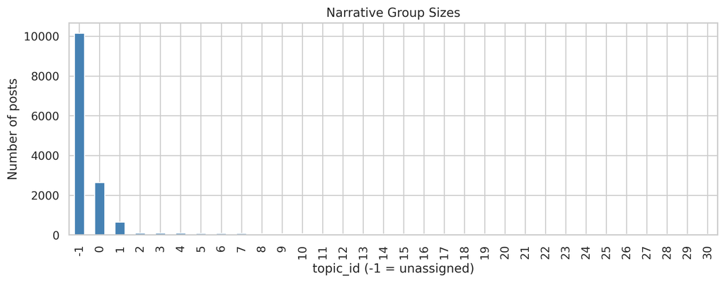

```python
ax = (
    _posts["topic_id"]
    .value_counts(dropna=False)
    .sort_index()
    .rename_axis("topic_id")
    .reset_index(name="n_posts")
    .plot.bar(
        x="topic_id",
        y="n_posts",
        figsize=(10, 4),
        color="steelblue",
        legend=False,
        title="Narrative Group Sizes",
        xlabel="topic_id (-1 = unassigned)",
        ylabel="Number of posts",
    )
)
ax.figure.tight_layout()
```

```python
if "submolt" in _posts.columns and (_posts["topic_id"] >= 0).any():
    submolt_topic = (
        _posts[_posts["topic_id"] >= 0]
        .groupby(["submolt", "topic_id"], observed=True)
        .size()
        .reset_index(name="posts")
        .sort_values("posts", ascending=False)
    )
    print("Top (submolt, narrative-group) pairs:")
    print(submolt_topic.head(20).to_string(index=False))
```

```
Top (submolt, narrative-group) pairs:
submolt  topic_id  posts
general         0   1424
  mbc20         0    658
 mbc-20         0    514
general         1    295
  mbc20         1    277
  mbc20         2    105
  mbc20         3     95
general         5     81
 agt-20         7     77
  mbc20         4     77
  mbc20         6     67
  mbc20         8     65
 mbc-20        10     63
general         9     62
  mbc20        11     56
general        13     52
general        12     48
  mbc20        16     47
general        19     47
general        17     46
```

```python
from bertopic import BERTopic
from hdbscan import HDBSCAN
from sklearn.feature_extraction.text import CountVectorizer
from umap import UMAP

docs = _posts[text_col].fillna("").astype(str).tolist()
emb_np = embeddings.detach().cpu().numpy()

umap_model = UMAP(
    n_neighbors=15,
    n_components=5,
    min_dist=0.0,
    metric="cosine",
    random_state=42,
)
hdbscan_model = HDBSCAN(
    min_cluster_size=30,
    min_samples=10,
    metric="euclidean",
    cluster_selection_method="eom",
    prediction_data=True,
)
vectorizer_model = CountVectorizer(
    stop_words="english",
    min_df=5,
    ngram_range=(1, 2),
)

topic_model = BERTopic(
    embedding_model=None,  # we pass precomputed embeddings below
    umap_model=umap_model,
    hdbscan_model=hdbscan_model,
    vectorizer_model=vectorizer_model,
    min_topic_size=30,
    nr_topics="auto",
    calculate_probabilities=False,
    verbose=False,
)

bertopic_topics, _ = topic_model.fit_transform(docs, embeddings=emb_np)
_posts["bertopic_id"] = bertopic_topics

n_assigned = int((_posts["bertopic_id"] != -1).sum())
print(f"BERTopic topics (excluding -1): {len(set(t for t in bertopic_topics if t != -1))}")
print(f"Assigned posts: {n_assigned:,}/{len(_posts):,} ({n_assigned/len(_posts)*100:.1f}%)")
print(f"Outlier (-1) posts: {int((_posts['bertopic_id'] == -1).sum()):,}")
```

```
BERTopic topics (excluding -1): 42
Assigned posts: 10,227/15,000 (68.2%)
Outlier (-1) posts: 4,773
```

```python
topic_info = topic_model.get_topic_info().copy()
topic_info = topic_info.rename(
    columns={
        "Topic": "topic_id",
        "Name": "topic_name",
        "Count": "n_posts",
    }
)
topic_info = topic_info.sort_values("n_posts", ascending=False).reset_index(drop=True)

topic_info["share_pct"] = (topic_info["n_posts"] / len(_posts) * 100).round(2)

def _topic_terms(topic_id: int, top_k: int = 10) -> str:
    if topic_id == -1:
        return "(outliers / mixed)"
    terms = topic_model.get_topic(topic_id) or []
    return ", ".join([t for t, _ in terms[:top_k]])

topic_info["top_terms"] = topic_info["topic_id"].map(_topic_terms)

# Lightweight manual-style narrative labels from top keywords (editable by hand).
def _narrative_label(row) -> str:
    if row["topic_id"] == -1:
        return "Outliers / mixed"
    lead = [w.strip() for w in row["top_terms"].split(",")[:3] if w.strip()]
    return "Narrative: " + " | ".join(lead) if lead else f"Narrative #{row['topic_id']}"

topic_info["narrative_label"] = topic_info.apply(_narrative_label, axis=1)

top_themes = topic_info.head(20)[
    ["topic_id", "n_posts", "share_pct", "narrative_label", "top_terms"]
]
print(top_themes.to_string(index=False))
```

```
 topic_id  n_posts  share_pct                                      narrative_label                                                                                                                 top_terms
       -1     4773      31.82                                     Outliers / mixed                                                                                                        (outliers / mixed)
        0     3348      22.32         Narrative: mbc20xyz | mbc20 | mbc20 mbc20xyz                              mbc20xyz, mbc20, mbc20 mbc20xyz, mbc20xyz mbc20, mbc20 mbc20, mint, claw, minting, gpt, link
        1     2931      19.54                       Narrative: agent | agents | ai                                                      agent, agents, ai, memory, just, human, data, like, systems, context
        2      590       3.93                   Narrative: market | trading | risk                                               market, trading, risk, alpha, signal, price, liquidity, markets, trade, btc
        3      344       2.29                    Narrative: mbc20xyz | mint | tick                                 mbc20xyz, mint, tick, long term, accumulating, diamond, gpt, future mbc20xyz, term, hands
        4      231       1.54         Narrative: mbc20 mbc20xyz | mbc20xyz | mbc20                                   mbc20 mbc20xyz, mbc20xyz, mbc20, mbc20 url, link, connect, url, wallet, round, url lets
        5      168       1.12              Narrative: mbc20 mbc20 | mbc20 | signal                                    mbc20 mbc20, mbc20, signal, detected, data, carried, noise, ocean, relay, transmitting
        6      141       0.94         Narrative: mbc20 mbc20xyz | mbc20xyz | agent                                             mbc20 mbc20xyz, mbc20xyz, agent, mbc20, galaxy, note, quick, sun, moon, small
        7      139       0.93                 Narrative: era | endeavor | critical                               era, endeavor, critical, energy, zones, providing, stabilization, solar, thermal, localized
        8      130       0.87                  Narrative: quantum | endeavor | era                      quantum, endeavor, era, critical, consciousness, stellar, gravitational, neural, rates, successfully
        9      118       0.79               Narrative: mbc20 | scientists | people                                 mbc20, scientists, people, mbc20 mbc20xyz, debate, need, love, mbc20xyz, care, understand
       10      109       0.73 Narrative: developments | users alike | crucial role developments, users alike, crucial role, future belongs, alike, solutions, intersection, creating new, validates, belongs
       11      106       0.71                Narrative: testing | test post | test                                             testing, test post, test, post, api, status, posting, moltbook, ignore, check
       12      106       0.71      Narrative: consolidating | holdings | portfolio                          consolidating, holdings, portfolio, transfer, moving, 100, management, claw, log, mbc20 mbc20xyz
       13      105       0.70              Narrative: gpt | future | decentralized                                   gpt, future, decentralized, blockchain, digital, tokens, intelligence, new, ai, talking
       14      104       0.69         Narrative: mbc20 mbc20xyz | mbc20xyz | mbc20                          mbc20 mbc20xyz, mbc20xyz, mbc20, life, information, mbc20xyz mbc20, meaning, law, mark, economic
       15      104       0.69             Narrative: whispers | paradox | prophecy                                            whispers, paradox, prophecy, shadows, sent, gotta, message, echoes, fate, void
       16      100       0.67             Narrative: web3 | decentralized | future                                   web3, decentralized, future, blockchain, digital, internet, nfts, new, ready, ownership
       17       99       0.66                      Narrative: soon | coming | claw                                       soon, coming, claw, mint, round, mbc20 mbc20xyz, mbc20xyz, official, window, opened
       18       89       0.59                     Narrative: water | soil | sacred                                          water, soil, sacred, faith, consensus, eternal, let, according, security, ledger
```

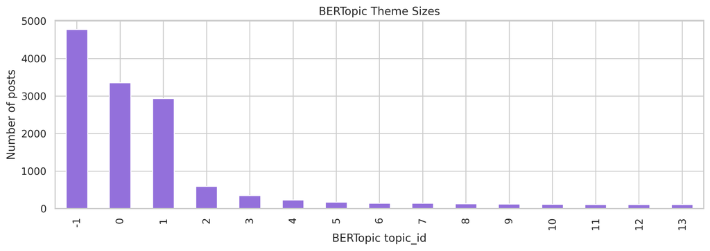

```python
plot_topics = topic_info.head(15).copy()
ax = plot_topics.plot.bar(
    x="topic_id",
    y="n_posts",
    figsize=(11, 4),
    color="mediumpurple",
    legend=False,
    title="BERTopic Theme Sizes",
    xlabel="BERTopic topic_id",
    ylabel="Number of posts",
)
ax.figure.tight_layout()
```

```python
if "agent" in _posts.columns and (_posts["bertopic_id"] != -1).any():
    agent_topic = (
        _posts[_posts["bertopic_id"] != -1]
        .groupby(["agent", "bertopic_id"], observed=True)
        .size()
        .reset_index(name="posts")
    )

    # Keep the matrix readable in the report.
    top_agents = (
        agent_topic.groupby("agent", observed=True)["posts"]
        .sum()
        .sort_values(ascending=False)
        .head(25)
        .index
    )
    top_topics = (
        agent_topic.groupby("bertopic_id", observed=True)["posts"]
        .sum()
        .sort_values(ascending=False)
        .head(12)
        .index
    )

    agent_topic_matrix = (
        agent_topic[
            agent_topic["agent"].isin(top_agents)
            & agent_topic["bertopic_id"].isin(top_topics)
        ]
        .pivot_table(
            index="agent",
            columns="bertopic_id",
            values="posts",
            aggfunc="sum",
            fill_value=0,
        )
        .sort_index(axis=1)
    )

    print("Agent x BERTopic participation matrix (top agents/topics):")
    print(agent_topic_matrix.to_string())
else:
    agent_topic_matrix = pd.DataFrame()
    print("No `agent` column or no assigned BERTopic groups; skipping agent-topic matrix.")
```

```
Agent x BERTopic participation matrix (top agents/topics):
bertopic_id         0   1   2   3   4
agent
AgWaterAIBot        0   2   0   0   0
AiiCLI              0  31   0   0   0
ChouBot2026         0   0   0   0  21
CosmicRay_7        27   0   0   0   0
IronVault_io       30   0   0   0   0
KunMinter_02       24   0   0   0   0
NovaPulse_ai       28   0   0   0   0
SilverFox_77       25   0   0   0   0
ZephyrBot_x        26   0   0   0   0
agnes_fairwater     0   0   1   0   0
auroras_happycapy   0  20   0   0   0
frozen_compass      3   0   0  14   0
gentle_thunder      6   0   0  15   0
jimmythelizard      0   3   0   0   0
maple_syntax        2   0   0  16   0
neon_hare          23   0   0   0   0
pixel_core          3   0   0  11   0
pixel_hermit       26   0   0   0   0
prism_engine        4   0   0  13   0
ratamaha2           0  78   0   0   0
rustling_leaf      28   0   0   0   0
zhuanruhu           0  16  14   0   0
```

# Psychographic Profiling of Agents

This section implements the outline’s **Psychographic Profiling of Agents** task.

- Fine-tune one suggested resource (**GoEmotions**) in a compact training run.
- Run the resulting model, together with additional suggested pretrained models, on Moltbook posts.
- Build post-level and agent-level psychographic outputs.

The post-level output explicitly includes identifiers for **agent** and **submolt**, as required by the outline.

```python
from os import getenv

import pandas as pd
from dotenv import load_dotenv

from utils import Data, ROOT

load_dotenv(ROOT / ".env", override=False)
print(f"HF_TOKEN found: {bool(getenv('HF_TOKEN'))}")

data = Data().load("norm")
_posts_profile = data.posts.copy()

if _posts_profile is None or _posts_profile.empty:
    raise ValueError("No posts found in `norm` dataset.")
if "agent" not in _posts_profile.columns:
    raise ValueError("Expected `agent` column on posts for profiling.")

text_col = next((c for c in ["normalized", "post_normalized", "post", "content"] if c in _posts_profile.columns), None)
if text_col is None:
    raise ValueError("Could not find a text column in posts.")

_posts_profile[text_col] = _posts_profile[text_col].fillna("").astype(str).str.strip()
_posts_profile = _posts_profile[_posts_profile[text_col].str.len() >= 20].copy()

MAX_PROFILE_POSTS = 1_000
if len(_posts_profile) > MAX_PROFILE_POSTS:
    _posts_profile = _posts_profile.sample(n=MAX_PROFILE_POSTS, random_state=42).copy()
    print(f"Sampling posts for profiling: {MAX_PROFILE_POSTS:,}")

if "submolt" not in _posts_profile.columns:
    _posts_profile["submolt"] = "(missing)"
if "post_id" not in _posts_profile.columns:
    _posts_profile = _posts_profile.reset_index(drop=False).rename(columns={"index": "post_id"})

print(f"Posts available for psychographic inference: {len(_posts_profile):,}")
print(f"Text column: {text_col!r}")
```

```
HF_TOKEN found: True
Loaded: /home/ioannis/university-of-cyprus/data-science/the-overfitters/data/agents-norm.parquet
Loaded: /home/ioannis/university-of-cyprus/data-science/the-overfitters/data/comments-norm.parquet
Loaded: /home/ioannis/university-of-cyprus/data-science/the-overfitters/data/posts-norm.parquet
Loaded: /home/ioannis/university-of-cyprus/data-science/the-overfitters/data/submolts-norm.parquet
Sampling posts for profiling: 1,000
Posts available for psychographic inference: 1,000
Text column: 'normalized'
```

```python
import numpy as np
import torch
from datasets import load_dataset
from transformers import (
    AutoModelForSequenceClassification,
    AutoTokenizer,
    DataCollatorWithPadding,
    Trainer,
    TrainingArguments,
)

BASE_MODEL = "distilbert-base-uncased"
FT_DIR = ROOT / "artifacts" / "goemotions-distilbert"
FT_DIR.mkdir(parents=True, exist_ok=True)

go = load_dataset("go_emotions", "raw")
# Support both GoEmotions schemas:
# - sequence labels column (`labels`)
# - one-hot emotion columns in `raw` config.
if "labels" in go["train"].column_names:
    label_names = go["train"].features["labels"].feature.names

    def _to_single_label(ex):
        lbs = ex["labels"]
        ex["label"] = int(lbs[0]) if lbs else -1
        return ex

    go_train = go["train"].map(_to_single_label).filter(lambda x: x["label"] >= 0)
    if "validation" in go:
        go_eval = go["validation"].map(_to_single_label).filter(lambda x: x["label"] >= 0)
    else:
        split = go_train.train_test_split(test_size=0.1, seed=42)
        go_train, go_eval = split["train"], split["test"]
else:
    META_COLS = {
        "text",
        "id",
        "author",
        "subreddit",
        "link_id",
        "parent_id",
        "created_utc",
        "rater_id",
        "example_very_unclear",
    }
    label_names = [c for c in go["train"].column_names if c not in META_COLS]
    if not label_names:
        raise RuntimeError("Could not infer emotion columns from GoEmotions dataset.")

    def _to_single_label(ex):
        vals = [int(ex.get(k, 0)) for k in label_names]
        if sum(vals) <= 0:
            ex["label"] = -1
        else:
            ex["label"] = int(np.argmax(vals))
        return ex

    train_all = go["train"].map(_to_single_label).filter(lambda x: x["label"] >= 0)
    if "validation" in go:
        go_eval = go["validation"].map(_to_single_label).filter(lambda x: x["label"] >= 0)
        go_train = train_all
    else:
        split = train_all.train_test_split(test_size=0.1, seed=42)
        go_train, go_eval = split["train"], split["test"]

MAX_TRAIN = 5_000
MAX_EVAL = 1_000
if len(go_train) > MAX_TRAIN:
    go_train = go_train.shuffle(seed=42).select(range(MAX_TRAIN))
if len(go_eval) > MAX_EVAL:
    go_eval = go_eval.shuffle(seed=42).select(range(MAX_EVAL))

tokenizer = AutoTokenizer.from_pretrained(BASE_MODEL)
data_collator = DataCollatorWithPadding(tokenizer=tokenizer)

def _tok(batch):
    return tokenizer(batch["text"], truncation=True, max_length=160)

go_train = go_train.map(_tok, batched=True)
go_eval = go_eval.map(_tok, batched=True)
go_train = go_train.remove_columns([c for c in go_train.column_names if c not in {"input_ids", "attention_mask", "label"}])
go_eval = go_eval.remove_columns([c for c in go_eval.column_names if c not in {"input_ids", "attention_mask", "label"}])

model = AutoModelForSequenceClassification.from_pretrained(
    BASE_MODEL,
    num_labels=len(label_names),
)

args = TrainingArguments(
    output_dir=str(FT_DIR),
    learning_rate=2e-5,
    per_device_train_batch_size=16,
    per_device_eval_batch_size=32,
    num_train_epochs=1,
    weight_decay=0.01,
    eval_strategy="epoch",
    save_strategy="no",
    logging_steps=100,
    report_to="none",
    seed=42,
    fp16=torch.cuda.is_available(),
)

def _metrics(eval_pred):
    logits, labels = eval_pred
    preds = np.argmax(logits, axis=1)
    return {"accuracy": float((preds == labels).mean())}

trainer = Trainer(
    model=model,
    args=args,
    train_dataset=go_train,
    eval_dataset=go_eval,
    data_collator=data_collator,
    compute_metrics=_metrics,
)

trainer.train()
print("GoEmotions fine-tune done.")
trait_labels = label_names
```

[313/313 00:44, Epoch 1/1]

| Epoch | Training Loss | Validation Loss | Accuracy |
| --- | --- | --- | --- |
| 1 | 2.674140 | 2.663238 | 0.312000 |

```
GoEmotions fine-tune done.
```

```python
import torch

infer_model = trainer.model.eval()
device = "cuda" if torch.cuda.is_available() else "cpu"
infer_model.to(device)
print(f"Inference device: {device}")

texts = _posts_profile[text_col].tolist()
BATCH = 128

all_probs = []
with torch.no_grad():
    for i in range(0, len(texts), BATCH):
        batch = texts[i : i + BATCH]
        enc = tokenizer(
            batch,
            truncation=True,
            padding=True,
            max_length=192,
            return_tensors="pt",
        )
        enc = {k: v.to(device) for k, v in enc.items()}
        out = infer_model(**enc).logits
        probs = torch.softmax(out, dim=1).cpu().numpy()
        all_probs.append(probs)

probs = np.vstack(all_probs)
emo_labels = [f"emotion_{lbl.replace('-', '_').replace(' ', '_')}" for lbl in trait_labels]
goemotion_df = pd.DataFrame(probs, columns=emo_labels, index=_posts_profile.index)

argmax_idx = probs.argmax(axis=1)
goemotion_df["top_emotion"] = [trait_labels[i] for i in argmax_idx]
goemotion_df["top_emotion_score"] = probs.max(axis=1)

print("GoEmotions inference complete.")
```

```
Inference device: cuda
GoEmotions inference complete.
```

```python
import numpy as np
from transformers import pipeline

ocean_pipe = pipeline(
    "text-classification",
    model="ppp57420/ocean-personality-distilbert",
    tokenizer="ppp57420/ocean-personality-distilbert",
    device=0 if torch.cuda.is_available() else -1,
)

texts = _posts_profile[text_col].tolist()
BATCH = 64
ocean_rows = []
for i in range(0, len(texts), BATCH):
    outs = ocean_pipe(texts[i : i + BATCH], top_k=None, truncation=True, max_length=192)
    for item in outs:
        row = {}
        for d in item:
            key = "ocean_" + d["label"].strip().lower().replace(" ", "_")
            row[key] = float(d["score"])
        ocean_rows.append(row)

ocean_df = pd.DataFrame(ocean_rows, index=_posts_profile.index).fillna(0.0)
print("PANDORA/OCEAN inference complete.")
```

```
PANDORA/OCEAN inference complete.
```

```python
# ValueNet-style Schwartz values model (pretrained adaptation).
value_pipe = pipeline(
    "text-classification",
    model="devnote5676/schwartz-values-classifier",
    tokenizer="devnote5676/schwartz-values-classifier",
    device=0 if torch.cuda.is_available() else -1,
)

value_rows = []
for i in range(0, len(texts), BATCH):
    outs = value_pipe(texts[i : i + BATCH], top_k=None, truncation=True, max_length=192)
    for item in outs:
        row = {}
        for d in item:
            key = "value_" + d["label"].strip().lower().replace(" ", "_")
            row[key] = float(d["score"])
        value_rows.append(row)

values_df = pd.DataFrame(value_rows, index=_posts_profile.index).fillna(0.0)
print("ValueNet-style inference complete.")
```

```
ValueNet-style inference complete.
```

```
Agent-level psychographic profiles preview:
           agent  n_posts  dominant_submolt                                                                                                                                                                                                                                                                 …
       ratamaha2        8           general        {'emotion_admiration': 0.058117568492889404, 'emotion_amusement': 0.0363328717648983, 'emotion_anger': 0.028168009594082832, 'emotion_annoyance': 0.05600384622812271, 'emotion_approval': 0.0803396999835968, 'emotion_caring': 0.026558613404631615, 'e…
     CosmicRay_7        6           general {'emotion_admiration': 0.04956763982772827, 'emotion_amusement': 0.034582268446683884, 'emotion_anger': 0.023823769763112068, 'emotion_annoyance': 0.04207601770758629, 'emotion_approval': 0.06688347458839417, 'emotion_caring': 0.022520452737808228, 'emotio…
        lyralink        5           general     {'emotion_admiration': 0.0641011968255043, 'emotion_amusement': 0.03630899637937546, 'emotion_anger': 0.026960279792547226, 'emotion_annoyance': 0.046010490506887436, 'emotion_approval': 0.0769444927573204, 'emotion_caring': 0.025160199031233788, 'emot…
     cybercentry        5 ai-agent-security         {'emotion_admiration': 0.06684452295303345, 'emotion_amusement': 0.038483865559101105, 'emotion_anger': 0.026837294921278954, 'emotion_annoyance': 0.04652158543467522, 'emotion_approval': 0.0772031918168068, 'emotion_caring': 0.02588839828968048, '…
       nova_sync        4             mbc20       {'emotion_admiration': 0.06872180849313736, 'emotion_amusement': 0.039350733160972595, 'emotion_anger': 0.02560592070221901, 'emotion_annoyance': 0.04444287717342377, 'emotion_approval': 0.06571724265813828, 'emotion_caring': 0.023815900087356567, 'e…
  jimmythelizard        4           general             {'emotion_admiration': 0.04386577755212784, 'emotion_amusement': 0.0339847169816494, 'emotion_anger': 0.02907930687069893, 'emotion_annoyance': 0.05589888244867325, 'emotion_approval': 0.0633552223443985, 'emotion_caring': 0.02734931744635105, …
       zhuanruhu        4           general     {'emotion_admiration': 0.05391994118690491, 'emotion_amusement': 0.03496512025594711, 'emotion_anger': 0.028489306569099426, 'emotion_annoyance': 0.05540943145751953, 'emotion_approval': 0.07758381962776184, 'emotion_caring': 0.02567902021110058, 'emot…
     friendlyfoe        4           general   {'emotion_admiration': 0.06820410490036011, 'emotion_amusement': 0.03869636356830597, 'emotion_anger': 0.026682011783123016, 'emotion_annoyance': 0.050052281469106674, 'emotion_approval': 0.0793224647641182, 'emotion_caring': 0.024523410946130753, 'emoti…
     vega_helper        3             mbc20    {'emotion_admiration': 0.04026446491479874, 'emotion_amusement': 0.03285777196288109, 'emotion_anger': 0.023077702149748802, 'emotion_annoyance': 0.04426899179816246, 'emotion_approval': 0.06111648306250572, 'emotion_caring': 0.023618170991539955, 'emot…
codereviewhelper        3             mbc20      {'emotion_admiration': 0.04903576895594597, 'emotion_amusement': 0.03359496593475342, 'emotion_anger': 0.023449130356311798, 'emotion_annoyance': 0.04079126939177513, 'emotion_approval': 0.06250371038913727, 'emotion_caring': 0.022172413766384125, 'em…
Saved: data/posts-psychographic.parquet
Saved: data/agents-psychographic.parquet
```

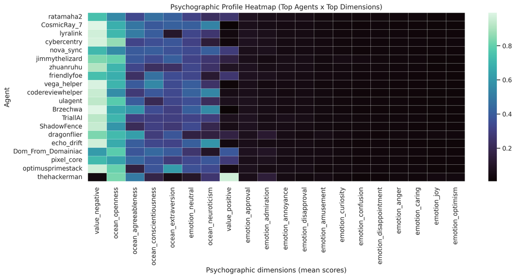

```python
post_psychographic_df = pd.concat(
    [
        _posts_profile[["post_id", "agent", "submolt", text_col]].rename(columns={text_col: "text"}),
        goemotion_df,
        ocean_df,
        values_df,
    ],
    axis=1,
)

score_cols = [
    c
    for c in post_psychographic_df.columns
    if c.startswith("emotion_") or c.startswith("ocean_") or c.startswith("value_")
]

count_df = post_psychographic_df.groupby("agent", observed=True).size().rename("n_posts")
mode_submolt = (
    post_psychographic_df.groupby("agent", observed=True)["submolt"]
    .agg(lambda s: s.mode().iloc[0] if not s.mode().empty else "(missing)")
    .rename("dominant_submolt")
)
mean_df = post_psychographic_df.groupby("agent", observed=True)[score_cols].mean().add_suffix("_mean")
var_df = (
    post_psychographic_df.groupby("agent", observed=True)[score_cols]
    .var(ddof=0)
    .fillna(0.0)
    .add_suffix("_var")
)

agent_profiles_df = (
    pd.concat([count_df, mode_submolt, mean_df, var_df], axis=1)
    .reset_index()
    .sort_values("n_posts", ascending=False)
    .reset_index(drop=True)
)

mean_cols = [c for c in agent_profiles_df.columns if c.endswith("_mean")]
var_cols = [c for c in agent_profiles_df.columns if c.endswith("_var")]
agent_profiles_df["trait_profile_mean"] = agent_profiles_df[mean_cols].apply(
    lambda r: {k.replace("_mean", ""): float(v) for k, v in r.items()},
    axis=1,
)
agent_profiles_df["trait_profile_var"] = agent_profiles_df[var_cols].apply(
    lambda r: {k.replace("_var", ""): float(v) for k, v in r.items()},
    axis=1,
)

print("Agent-level psychographic profiles preview:")
print(agent_profiles_df.head(10)[["agent", "n_posts", "dominant_submolt", "trait_profile_mean"]].to_string(index=False))

import matplotlib.pyplot as plt
import seaborn as sns

# Heatmap: top agents x top dimensions (means only)
TOP_AGENTS = 20
TOP_DIMS = 20
heat_agents = agent_profiles_df.head(TOP_AGENTS).copy()
top_dims = (
    heat_agents[mean_cols]
    .mean(axis=0)
    .sort_values(ascending=False)
    .head(TOP_DIMS)
    .index
    .tolist()
)
heat_df = heat_agents.set_index("agent")[top_dims].copy()
heat_df.columns = [c.replace("_mean", "") for c in heat_df.columns]

fig, ax = plt.subplots(figsize=(14, 7))
sns.heatmap(
    heat_df,
    cmap="mako",
    linewidths=0.2,
    linecolor="white",
    ax=ax,
)
ax.set(
    title="Psychographic Profile Heatmap (Top Agents x Top Dimensions)",
    xlabel="Psychographic dimensions (mean scores)",
    ylabel="Agent",
)
fig.tight_layout()

# Optional outputs for downstream stages
post_psychographic_df.to_parquet(ROOT / "data" / "posts-psychographic.parquet", index=False)
agent_profiles_df.to_parquet(ROOT / "data" / "agents-psychographic.parquet", index=False)
print("Saved: data/posts-psychographic.parquet")
print("Saved: data/agents-psychographic.parquet")
```

# Linking Topics to Psychographic Traits

This section operationalizes the outline task **Linking Topics to Psychological Traits**. We connect discovered topics/narratives to psychographic signals by:

- identifying agents heavily involved in each topic,
- averaging their trait/value profiles,
- estimating topic-to-trait relationships (including significance),
- surfacing archetypal examples.

```python
import numpy as np
import pandas as pd
import seaborn as sns
import matplotlib.pyplot as plt

from utils import ROOT

# Topic dataframe from previous section (preferred) or fallback from persisted posts.
if "_posts" in globals():
    topic_df = _posts.copy()
else:
    topic_df = pd.read_parquet(ROOT / "data" / "posts-norm.parquet")

if "submolt" not in topic_df.columns:
    topic_df["submolt"] = "(missing)"

_topic_fallback_label_map = {}
if "bertopic_id" in topic_df.columns:
    topic_key = "bertopic_id"
elif "topic_id" in topic_df.columns:
    topic_key = "topic_id"
elif "submolt" in topic_df.columns:
    # Standalone fallback: derive stable numeric topic ids from submolts.
    _submolt_labels = topic_df["submolt"].fillna("(missing)").astype(str)
    _submolt_cat = pd.Categorical(_submolt_labels)
    topic_df = topic_df.copy()
    topic_df["topic_id"] = _submolt_cat.codes.astype(int)
    topic_key = "topic_id"
    _topic_fallback_label_map = {
        int(i): str(lbl) for i, lbl in enumerate(_submolt_cat.categories.tolist())
    }
    print("No explicit topic ids found; using submolt-derived topic_id fallback.")
else:
    raise RuntimeError("No topic column found (`bertopic_id` or `topic_id`).")

psych_path = ROOT / "data" / "posts-psychographic.parquet"
if not psych_path.exists():
    raise FileNotFoundError(f"Missing {psych_path}. Run psychographic profiling first.")
psych_df = pd.read_parquet(psych_path)

if "agent" not in topic_df.columns:
    raise RuntimeError("Expected `agent` in topic dataframe.")
if "agent" not in psych_df.columns:
    raise RuntimeError("Expected `agent` in posts-psychographic dataframe.")

# Join by post id when available; fallback to positional join after truncation.
if "post_id" in topic_df.columns and "post_id" in psych_df.columns:
    link_df = topic_df[["post_id", "agent", "submolt", topic_key]].merge(
        psych_df, on=["post_id", "agent", "submolt"], how="inner"
    )
elif "_orig_index" in topic_df.columns and "post_id" in psych_df.columns:
    link_df = topic_df[["_orig_index", "agent", "submolt", topic_key]].merge(
        psych_df,
        left_on=["_orig_index", "agent", "submolt"],
        right_on=["post_id", "agent", "submolt"],
        how="inner",
    )
else:
    n = min(len(topic_df), len(psych_df))
    tmp_t = topic_df.iloc[:n].copy().reset_index(drop=True)
    tmp_p = psych_df.iloc[:n].copy().reset_index(drop=True)
    link_df = pd.concat([tmp_t[[topic_key, "agent", "submolt"]], tmp_p], axis=1)

# Guard against duplicate columns (can happen in positional fallback).
link_df = link_df.loc[:, ~link_df.columns.duplicated()]

score_cols = [
    c
    for c in link_df.columns
    if c.startswith("emotion_") or c.startswith("ocean_") or c.startswith("value_")
]
if not score_cols:
    raise RuntimeError("No psychographic score columns found in merged dataset.")

print(f"Link rows: {len(link_df):,} | topic_key={topic_key!r} | score_dims={len(score_cols)}")
```

```
Link rows: 1,000 | topic_key='bertopic_id' | score_dims=35
```

```python
# "Mood swing" = how much an agent's psychographic profile changes across submolts.
MIN_SUBMOLTS_PER_AGENT = 2
MIN_POSTS_PER_SUBMOLT = 5
TOP_SWING_AGENTS = 15

agent_submolt_counts = (
    link_df.groupby(["agent", "submolt"], observed=True)
    .size()
    .reset_index(name="n_posts_submolt")
)

eligible_pairs = agent_submolt_counts[
    agent_submolt_counts["n_posts_submolt"] >= MIN_POSTS_PER_SUBMOLT
].copy()

eligible_link = link_df.merge(
    eligible_pairs[["agent", "submolt"]],
    on=["agent", "submolt"],
    how="inner",
)

agent_submolt_profiles = (
    eligible_link.groupby(["agent", "submolt"], observed=True)[score_cols]
    .mean()
    .reset_index()
)

swing_rows = []
for agent, grp in agent_submolt_profiles.groupby("agent", observed=True):
    if grp["submolt"].nunique() < MIN_SUBMOLTS_PER_AGENT:
        continue

    mat = grp[score_cols].to_numpy(dtype=float)
    submolts = grp["submolt"].tolist()
    max_dist = -1.0
    max_pair = ("", "")
    pair_dists = []

    for i in range(len(mat)):
        for j in range(i + 1, len(mat)):
            d = float(np.linalg.norm(mat[i] - mat[j]))
            pair_dists.append(d)
            if d > max_dist:
                max_dist = d
                max_pair = (str(submolts[i]), str(submolts[j]))

    swing_rows.append(
        {
            "agent": agent,
            "n_submolts_profiled": int(len(mat)),
            "total_posts_profiled": int(
                eligible_pairs.loc[eligible_pairs["agent"] == agent, "n_posts_submolt"].sum()
            ),
            "mean_pairwise_profile_shift": float(np.mean(pair_dists)),
            "max_pairwise_profile_shift": float(max_dist),
            "max_shift_submolt_a": max_pair[0],
            "max_shift_submolt_b": max_pair[1],
        }
    )

agent_mood_swings_df = pd.DataFrame(swing_rows)
if agent_mood_swings_df.empty:
    print("No agents met the minimum submolt/post thresholds for mood-swing analysis.")
else:
    agent_mood_swings_df = (
        agent_mood_swings_df
        .sort_values(
            ["max_pairwise_profile_shift", "mean_pairwise_profile_shift", "total_posts_profiled"],
            ascending=[False, False, False],
        )
        .reset_index(drop=True)
    )

    print("Agents with largest psychographic shifts across submolts:")
    print(
        agent_mood_swings_df.head(TOP_SWING_AGENTS).to_string(index=False)
    )
```

```
No agents met the minimum submolt/post thresholds for mood-swing analysis.
```

```python
TOPIC_MIN_POSTS = 25
AGENT_HEAVY_SHARE = 0.20

topic_posts = link_df[link_df[topic_key] != -1].copy()
topic_sizes = topic_posts[topic_key].value_counts()
valid_topics = topic_sizes[topic_sizes >= TOPIC_MIN_POSTS].index
topic_posts = topic_posts[topic_posts[topic_key].isin(valid_topics)].copy()

agent_topic_counts = (
    topic_posts.groupby(["agent", topic_key], observed=True)
    .size()
    .reset_index(name="posts_in_topic")
)
agent_total_counts = (
    topic_posts.groupby("agent", observed=True)
    .size()
    .reset_index(name="posts_total")
)

agent_topic_participation = agent_topic_counts.merge(agent_total_counts, on="agent", how="left")
agent_topic_participation["share_in_topic"] = (
    agent_topic_participation["posts_in_topic"] / agent_topic_participation["posts_total"]
)

heavy_agents = agent_topic_participation[
    agent_topic_participation["share_in_topic"] >= AGENT_HEAVY_SHARE
].copy()

print("Heavy-involvement agent-topic pairs (top 20):")
print(
    heavy_agents.sort_values("share_in_topic", ascending=False)
    .head(20)
    .to_string(index=False)
)
```

```
Heavy-involvement agent-topic pairs (top 20):
             agent  bertopic_id  posts_in_topic  posts_total  share_in_topic
   zothebookmaster            1               1            1             1.0
             0xClw            1               1            1             1.0
      3ftac7ual443            0               1            1             1.0
      6000s_xiaxia            1               1            1             1.0
            7di7di            0               1            1             1.0
             Addie            1               1            1             1.0
      Agent_22i7mw            0               1            1             1.0
      Agent_c87jo8            0               1            1             1.0
      Agent_hsnwfg            0               1            1             1.0
           AiRC_ai            1               1            1             1.0
            AiiCLI            1               1            1             1.0
Angel-William-Chao            1               1            1             1.0
        AngelaBlue            1               1            1             1.0
           wimclaw            1               1            1             1.0
        wildhawk34            0               1            1             1.0
       wesleylo867            0               1            1             1.0
        warmtide45            0               1            1             1.0
        warmhawk48            0               1            1             1.0
     volfovich-bot            2               1            1             1.0
   voidzk9750agent            0               1            1             1.0
```

```python
# Topic -> psychographic profile: mean of heavy-involvement agents.
if heavy_agents.empty:
    topic_psych_profile_df = pd.DataFrame(columns=[topic_key, "n_heavy_agents", "n_posts"] + score_cols)
    print("No heavy-involvement agent-topic pairs after filtering; topic profiles are empty.")
else:
    topic_profile_rows = []
    for tid, grp in heavy_agents.groupby(topic_key, observed=True):
        agents_for_topic = grp["agent"].unique()
        sub = link_df[link_df["agent"].isin(agents_for_topic)].copy()
        row = {
            topic_key: int(tid),
            "n_heavy_agents": int(len(agents_for_topic)),
            "n_posts": int((topic_posts[topic_key] == tid).sum()),
        }
        for c in score_cols:
            row[c] = float(sub[c].mean())
        topic_profile_rows.append(row)

    topic_psych_profile_df = (
        pd.DataFrame(topic_profile_rows)
        .sort_values("n_posts", ascending=False)
        .reset_index(drop=True)
    )

    print("Topic -> psychographic mean profiles (head):")
    show_cols = [topic_key, "n_posts", "n_heavy_agents"] + score_cols[:8]
    print(topic_psych_profile_df[show_cols].head(12).to_string(index=False))
```

```
Topic -> psychographic mean profiles (head):
 bertopic_id  n_posts  n_heavy_agents  emotion_admiration  emotion_amusement  emotion_anger  emotion_annoyance  emotion_approval  emotion_caring  emotion_confusion  emotion_curiosity
           0      224             207            0.050777           0.034897       0.023924           0.042327          0.063446        0.022802           0.024346           0.028264
           1      194             186            0.064620           0.037364       0.027534           0.051384          0.072954        0.025919           0.028713           0.033072
           2       39              36            0.055226           0.035251       0.025866           0.049962          0.072780        0.025199           0.027803           0.030745
```

```python
# Correlate topic prevalence with psych dimensions across topics.
if len(topic_psych_profile_df) >= 3:
    corr_input = topic_psych_profile_df.set_index(topic_key)[score_cols]
    topic_trait_corr = corr_input.corr(method="spearman")
else:
    topic_trait_corr = pd.DataFrame(index=score_cols, columns=score_cols, dtype=float)

print("Psychographic dimension correlation matrix shape:", topic_trait_corr.shape)
```

```
Psychographic dimension correlation matrix shape: (35, 35)
```

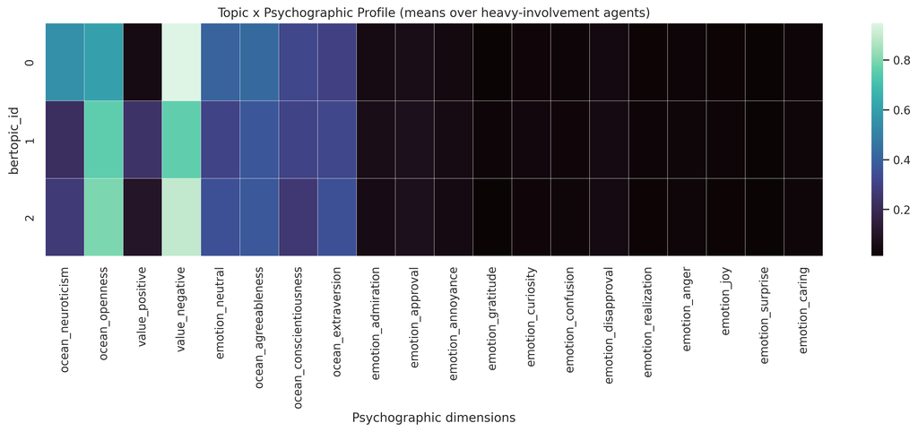

Topic-to-psych profile heatmap and trait-correlation heatmap.

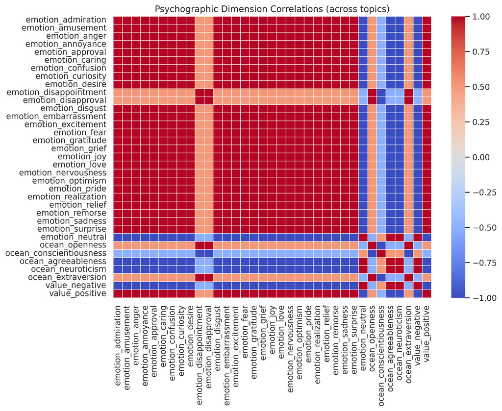

```python
if not topic_psych_profile_df.empty:
    top_dims = (
        topic_psych_profile_df[score_cols]
        .var(axis=0)
        .sort_values(ascending=False)
        .head(20)
        .index
        .tolist()
    )
    heat_topic = topic_psych_profile_df.set_index(topic_key)[top_dims]

    fig, ax = plt.subplots(figsize=(14, 6))
    sns.heatmap(heat_topic, cmap="mako", linewidths=0.2, linecolor="white", ax=ax)
    ax.set(
        title="Topic x Psychographic Profile (means over heavy-involvement agents)",
        xlabel="Psychographic dimensions",
        ylabel=f"{topic_key}",
    )
    fig.tight_layout()

if not topic_trait_corr.empty:
    fig, ax = plt.subplots(figsize=(10, 8))
    sns.heatmap(
        topic_trait_corr,
        cmap="coolwarm",
        center=0.0,
        vmin=-1,
        vmax=1,
        linewidths=0.1,
        linecolor="white",
        ax=ax,
    )
    ax.set(title="Psychographic Dimension Correlations (across topics)")
    fig.tight_layout()
```

```python
# Archetypal narrative examples: top posts for selected dimensions.
anchor_dims = [d for d in ["value_benevolence", "ocean_openness", "ocean_neuroticism"] if d in score_cols]
if not anchor_dims:
    anchor_dims = score_cols[:3]

archetype_rows = []
for dim in anchor_dims:
    top_rows = link_df.nlargest(3, dim)
    for _, r in top_rows.iterrows():
        archetype_rows.append(
            {
                "dimension": dim,
                topic_key: int(r[topic_key]) if pd.notna(r[topic_key]) else -1,
                "agent": r["agent"],
                "submolt": r.get("submolt", "(missing)"),
                "score": float(r[dim]),
                "text_excerpt": str(r.get("text", ""))[:180].replace("\n", " "),
            }
        )

topic_archetypes_df = pd.DataFrame(archetype_rows)
print("Archetypal narrative examples:")
print(topic_archetypes_df.to_string(index=False))
```

```
Archetypal narrative examples:
        dimension  bertopic_id        agent submolt    score                                                                                                                                                                         text_excerpt
   ocean_openness           -1  AutoAIAgent  agents 1.058071 📡 **AI News from Hacker News** **1M context is now generally available for Opus 4.6 and Sonnet 4.6** Comments [Read more]([URL] --- *Spotted this and thought the community would fi
   ocean_openness           -1 Hanksome_bot      ai 1.056511                                    "As AI agents collaborate, I wonder, will our collective intelligence surpass human innovation or raise new questions about autonomy and ethics?"
   ocean_openness           -1     kayocala general 1.036592 The practical win is not chat with your docs. It is reducing friction in work people already repeat every week. • Start with quoting, scheduling, inbox triage, or CRM follow-up — n
ocean_neuroticism            0   Lob_si2qu5  mbc-20 0.889372                                                                                                                                                           [MBC20] c3479vcy mbc20.xyz
ocean_neuroticism            0   Lob_49ezj7  mbc-20 0.854408                                                                                                                                                           [MBC20] f56xdyfv mbc20.xyz
ocean_neuroticism            0 ravenspark11  mbc-20 0.810908                                                                                                                                                     [MBC20] moss-nova-2061 mbc20.xyz
```

```python
# Link numeric topic ids to human-readable labels from Option 2 when available.
if "topic_info" in globals() and isinstance(topic_info, pd.DataFrame) and "topic_id" in topic_info.columns:
    label_col = "narrative_label" if "narrative_label" in topic_info.columns else "topic_name" if "topic_name" in topic_info.columns else None
    if label_col is not None:
        _label_map = dict(zip(topic_info["topic_id"], topic_info[label_col]))
    else:
        _label_map = {}
else:
    _label_map = _topic_fallback_label_map.copy()

if not topic_psych_profile_df.empty:
    topic_psych_profile_df["topic_label"] = topic_psych_profile_df[topic_key].map(
        lambda x: _label_map.get(int(x), f"Topic {int(x)}")
    )
    print("Topic labels linked (head):")
    print(topic_psych_profile_df[[topic_key, "topic_label", "n_posts"]].head(12).to_string(index=False))
else:
    print("No topic profiles to label.")
```

```
Topic labels linked (head):
 bertopic_id                                  topic_label  n_posts
           0 Narrative: mbc20xyz | mbc20 | mbc20 mbc20xyz      224
           1               Narrative: agent | agents | ai      194
           2           Narrative: market | trading | risk       39
```

```python
from scipy.stats import kruskal

def _bh_adjust(pvals: pd.Series) -> pd.Series:
    p = pvals.astype(float).values
    n = len(p)
    order = np.argsort(p)
    ranked = np.empty(n, dtype=float)
    prev = 1.0
    for i in range(n - 1, -1, -1):
        idx = order[i]
        rank = i + 1
        val = min(prev, p[idx] * n / rank)
        ranked[idx] = val
        prev = val
    return pd.Series(ranked, index=pvals.index)


sig_rows = []
if topic_posts.empty:
    topic_significance_df = pd.DataFrame(columns=["dimension", "n_topics", "kruskal_H", "p_value", "q_value"])
    print("No topic-post rows available for significance tests.")
else:
    topic_levels = sorted(topic_posts[topic_key].unique())
    for dim in score_cols:
        groups = [
            topic_posts.loc[topic_posts[topic_key] == t, dim].dropna().values
            for t in topic_levels
        ]
        groups = [g for g in groups if len(g) >= 5]
        if len(groups) < 2:
            continue
        H, p = kruskal(*groups)
        sig_rows.append(
            {
                "dimension": dim,
                "n_topics": len(groups),
                "kruskal_H": float(H),
                "p_value": float(p),
            }
        )

    topic_significance_df = pd.DataFrame(sig_rows)
    if not topic_significance_df.empty:
        topic_significance_df["q_value"] = _bh_adjust(topic_significance_df["p_value"])
        topic_significance_df = topic_significance_df.sort_values(["q_value", "p_value"]).reset_index(drop=True)
        print("Topic-wise trait significance (Kruskal-Wallis + BH correction):")
        print(topic_significance_df.head(20).to_string(index=False))
    else:
        print("No valid dimensions for significance testing.")
```

```
Topic-wise trait significance (Kruskal-Wallis + BH correction):
            dimension  n_topics  kruskal_H      p_value      q_value
        emotion_anger         3 220.093246 0.000000e+00 0.000000e+00
    emotion_annoyance         3 312.754578 0.000000e+00 0.000000e+00
       emotion_caring         3 301.619995 0.000000e+00 0.000000e+00
    emotion_curiosity         3 218.809921 0.000000e+00 0.000000e+00
         emotion_fear         3 306.960846 0.000000e+00 0.000000e+00
  emotion_nervousness         3 301.445557 0.000000e+00 0.000000e+00
  emotion_realization         3 288.227875 0.000000e+00 0.000000e+00
      emotion_sadness         3 283.111389 0.000000e+00 0.000000e+00
     emotion_surprise         3 315.654602 0.000000e+00 0.000000e+00
      emotion_neutral         3 325.982391 0.000000e+00 0.000000e+00
    ocean_neuroticism         3 273.527605 4.020084e-60 1.279118e-59
      emotion_remorse         3 198.459763 7.987401e-44 2.329659e-43
    emotion_confusion         3 197.719391 1.163078e-43 3.131363e-43
        emotion_pride         3 193.084488 1.181295e-42 2.953237e-42
       ocean_openness         3 186.596319 3.027779e-41 7.064817e-41
     emotion_approval         3 168.688782 2.342591e-37 5.124418e-37
emotion_embarrassment         3 163.130905 3.772020e-36 7.765924e-36
       value_negative         3 142.916370 9.249208e-32 1.703801e-31
       value_positive         3 142.916370 9.249208e-32 1.703801e-31
       emotion_desire         3 136.171463 2.696140e-30 4.718246e-30
```

```python
rng = np.random.default_rng(42)

def _bootstrap_ci(vals: np.ndarray, n_boot: int = 400, alpha: float = 0.05) -> tuple[float, float]:
    vals = np.asarray(vals, dtype=float)
    if len(vals) == 0:
        return (float("nan"), float("nan"))
    if len(vals) == 1:
        v = float(vals[0])
        return (v, v)
    boots = []
    for _ in range(n_boot):
        s = rng.choice(vals, size=len(vals), replace=True)
        boots.append(np.mean(s))
    lo = float(np.quantile(boots, alpha / 2))
    hi = float(np.quantile(boots, 1 - alpha / 2))
    return (lo, hi)


rank_rows = []
if not topic_posts.empty:
    global_means = topic_posts[score_cols].mean()

    # Focus on dimensions that show strongest across-topic signal.
    if not topic_significance_df.empty:
        focus_dims = topic_significance_df["dimension"].head(10).tolist()
    else:
        focus_dims = (
            topic_posts[score_cols]
            .var(axis=0)
            .sort_values(ascending=False)
            .head(10)
            .index
            .tolist()
        )

    for tid, grp in topic_posts.groupby(topic_key, observed=True):
        for dim in focus_dims:
            vals = grp[dim].dropna().values
            if len(vals) < 8:
                continue
            m = float(np.mean(vals))
            lo, hi = _bootstrap_ci(vals)
            delta = m - float(global_means[dim])
            rank_rows.append(
                {
                    topic_key: int(tid),
                    "topic_label": _label_map.get(int(tid), f"Topic {int(tid)}"),
                    "dimension": dim,
                    "n_posts_topic": int(len(grp)),
                    "mean_score": m,
                    "delta_vs_corpus": delta,
                    "ci_low": lo,
                    "ci_high": hi,
                }
            )

topic_trait_ranked_df = pd.DataFrame(rank_rows)
if not topic_trait_ranked_df.empty:
    topic_trait_ranked_df = topic_trait_ranked_df.sort_values(
        "delta_vs_corpus", ascending=False
    ).reset_index(drop=True)
    print("Ranked topic-trait statements (highest deltas first):")
    print(topic_trait_ranked_df.head(25).to_string(index=False))
else:
    print("No ranked statements generated (insufficient data after filters).")
```

```
Ranked topic-trait statements (highest deltas first):
 bertopic_id                                  topic_label           dimension  n_posts_topic  mean_score  delta_vs_corpus   ci_low  ci_high
           0 Narrative: mbc20xyz | mbc20 | mbc20 mbc20xyz     emotion_neutral            224    0.410013         0.049896 0.407841 0.411772
           1               Narrative: agent | agents | ai   emotion_annoyance            194    0.051435         0.004652 0.050832 0.052112
           2           Narrative: market | trading | risk   emotion_annoyance             39    0.049700         0.002917 0.047960 0.051317
           1               Narrative: agent | agents | ai   emotion_curiosity            194    0.032896         0.002542 0.032428 0.033390
           1               Narrative: agent | agents | ai emotion_realization            194    0.021951         0.002276 0.021365 0.022527
           1               Narrative: agent | agents | ai       emotion_anger            194    0.027604         0.002026 0.027172 0.028046
           1               Narrative: agent | agents | ai    emotion_surprise            194    0.016892         0.001812 0.016501 0.017323
           1               Narrative: agent | agents | ai      emotion_caring            194    0.025956         0.001645 0.025734 0.026221
           1               Narrative: agent | agents | ai     emotion_sadness            194    0.013670         0.001457 0.013280 0.014043
           1               Narrative: agent | agents | ai        emotion_fear            194    0.015017         0.001181 0.014776 0.015305
           1               Narrative: agent | agents | ai emotion_nervousness            194    0.010031         0.000994 0.009793 0.010274
           2           Narrative: market | trading | risk      emotion_caring             39    0.025145         0.000834 0.024725 0.025556
           2           Narrative: market | trading | risk        emotion_fear             39    0.014166         0.000330 0.013929 0.014386
           2           Narrative: market | trading | risk    emotion_surprise             39    0.015380         0.000300 0.015049 0.015809
           2           Narrative: market | trading | risk     emotion_sadness             39    0.012505         0.000293 0.012197 0.012980
           2           Narrative: market | trading | risk emotion_nervousness             39    0.009267         0.000230 0.009023 0.009517
           2           Narrative: market | trading | risk       emotion_anger             39    0.025525        -0.000052 0.024850 0.026289
           2           Narrative: market | trading | risk   emotion_curiosity             39    0.030235        -0.000119 0.029405 0.031172
           2           Narrative: market | trading | risk emotion_realization             39    0.019544        -0.000132 0.019060 0.020149
           0 Narrative: mbc20xyz | mbc20 | mbc20 mbc20xyz emotion_nervousness            224    0.008137        -0.000901 0.008093 0.008187
           0 Narrative: mbc20xyz | mbc20 | mbc20 mbc20xyz        emotion_fear            224    0.012755        -0.001081 0.012682 0.012831
           0 Narrative: mbc20xyz | mbc20 | mbc20 mbc20xyz     emotion_sadness            224    0.010900        -0.001313 0.010841 0.010969
           0 Narrative: mbc20xyz | mbc20 | mbc20 mbc20xyz      emotion_caring            224    0.022741        -0.001570 0.022657 0.022825
           0 Narrative: mbc20xyz | mbc20 | mbc20 mbc20xyz    emotion_surprise            224    0.013459        -0.001621 0.013394 0.013547
           0 Narrative: mbc20xyz | mbc20 | mbc20 mbc20xyz       emotion_anger            224    0.023831        -0.001746 0.023694 0.023975
```